# E-Commerce Data Analysis

1) Data Preparation  
2) Exploratory Data Analysis (EDA)  
2.1) How many orders for each country?  
2.2) How much money did each country spent?  
2.3) How were sales over the months?

- Average Ticket

2.4) How orders were distributed by day (of month)  
2.5) How orders were distributed by day (of week):  
2.6) How orders were distributed by hour?  
2.7) What are the most common stock codes?  
2.8) Which stock codes contribute the most to revenue?  
3) Categorizing Products  
3.1) Clearing Product Data  
3.2) Product Clustering

- Count Vectorizer
- TF-IDF

## 1) Data Preparation

Loading all the modules that will be used:

```python
import numpy as np
import pandas as pd
import matplotlib.pyplot as plt
import seaborn as sns
%matplotlib inline

sns.set_style('whitegrid')

from sklearn.linear_model import LinearRegression
from sklearn.preprocessing import PolynomialFeatures
from sklearn.feature_extraction.text import CountVectorizer
from sklearn.feature_extraction.text import TfidfVectorizer
from sklearn.cluster import KMeans

from nltk.corpus import stopwords
from nltk.stem import PorterStemmer
import string

from webcolors import CSS3_NAMES_TO_HEX

import warnings
warnings.filterwarnings(action='ignore', category=DeprecationWarning)
warnings.filterwarnings(action='ignore', category=FutureWarning)

from pandas_profiling import ProfileReport
```

Then reading the data set and taking the first look:

```python
df = pd.read_csv('../1985_3404_bundle_archive/data.csv', encoding = 'ISO-8859-1')
```

```python
df.head()
```

|  | InvoiceNo | StockCode | Description | Quantity | InvoiceDate | UnitPrice | CustomerID | Country |
| --- | --- | --- | --- | --- | --- | --- | --- | --- |
| 0 | 536365 | 85123A | WHITE HANGING HEART T-LIGHT HOLDER | 6 | 12/1/2010 8:26 | 2.55 | 17850.0 | United Kingdom |
| 1 | 536365 | 71053 | WHITE METAL LANTERN | 6 | 12/1/2010 8:26 | 3.39 | 17850.0 | United Kingdom |
| 2 | 536365 | 84406B | CREAM CUPID HEARTS COAT HANGER | 8 | 12/1/2010 8:26 | 2.75 | 17850.0 | United Kingdom |
| 3 | 536365 | 84029G | KNITTED UNION FLAG HOT WATER BOTTLE | 6 | 12/1/2010 8:26 | 3.39 | 17850.0 | United Kingdom |
| 4 | 536365 | 84029E | RED WOOLLY HOTTIE WHITE HEART. | 6 | 12/1/2010 8:26 | 3.39 | 17850.0 | United Kingdom |

Let's standardize the dataframe's columns and text, facilitating the handling.

```python
# New column names

new_cols = ['invoice_num', 'stock_code', 'description', 'quantity',
            'invoice_date', 'unit_price', 'customer_id', 'country']
df.columns = new_cols

df.head()
```

|  | invoice_num | stock_code | description | quantity | invoice_date | unit_price | customer_id | country |
| --- | --- | --- | --- | --- | --- | --- | --- | --- |
| 0 | 536365 | 85123A | WHITE HANGING HEART T-LIGHT HOLDER | 6 | 12/1/2010 8:26 | 2.55 | 17850.0 | United Kingdom |
| 1 | 536365 | 71053 | WHITE METAL LANTERN | 6 | 12/1/2010 8:26 | 3.39 | 17850.0 | United Kingdom |
| 2 | 536365 | 84406B | CREAM CUPID HEARTS COAT HANGER | 8 | 12/1/2010 8:26 | 2.75 | 17850.0 | United Kingdom |
| 3 | 536365 | 84029G | KNITTED UNION FLAG HOT WATER BOTTLE | 6 | 12/1/2010 8:26 | 3.39 | 17850.0 | United Kingdom |
| 4 | 536365 | 84029E | RED WOOLLY HOTTIE WHITE HEART. | 6 | 12/1/2010 8:26 | 3.39 | 17850.0 | United Kingdom |

```python
# New columns to represent stock code, description and country in lower case

# Lowercase stock code
df.loc[~df['stock_code'].isna(), 'lowercase_stockcode'] = df.loc[
                                                                 ~df['stock_code'].isna(), 'stock_code'
                                                                ].apply(lambda text: text.lower())

# Lowercase description
df.loc[~df['description'].isna(), 'lowercase_description'] = df.loc[
                                                                    ~df['description'].isna(), 'description'
                                                                   ].apply(lambda text: text.lower())

# Lowercase country
df.loc[~df['country'].isna(), 'lowercase_country'] = df.loc[
                                                            ~df['country'].isna(), 'country'
                                                           ].apply(lambda text: text.lower())
```

```python
df.head()
```

|  | invoice_num | stock_code | description | quantity | invoice_date | unit_price | customer_id | country | lowercase_stockcode | lowercase_description | lowercase_country |
| --- | --- | --- | --- | --- | --- | --- | --- | --- | --- | --- | --- |
| 0 | 536365 | 85123A | WHITE HANGING HEART T-LIGHT HOLDER | 6 | 12/1/2010 8:26 | 2.55 | 17850.0 | United Kingdom | 85123a | white hanging heart t-light holder | united kingdom |
| 1 | 536365 | 71053 | WHITE METAL LANTERN | 6 | 12/1/2010 8:26 | 3.39 | 17850.0 | United Kingdom | 71053 | white metal lantern | united kingdom |
| 2 | 536365 | 84406B | CREAM CUPID HEARTS COAT HANGER | 8 | 12/1/2010 8:26 | 2.75 | 17850.0 | United Kingdom | 84406b | cream cupid hearts coat hanger | united kingdom |
| 3 | 536365 | 84029G | KNITTED UNION FLAG HOT WATER BOTTLE | 6 | 12/1/2010 8:26 | 3.39 | 17850.0 | United Kingdom | 84029g | knitted union flag hot water bottle | united kingdom |
| 4 | 536365 | 84029E | RED WOOLLY HOTTIE WHITE HEART. | 6 | 12/1/2010 8:26 | 3.39 | 17850.0 | United Kingdom | 84029e | red woolly hottie white heart. | united kingdom |

Creating a report to get an overview of the data:

```python
# This doesn't appear on github, but the design is great
# It is used only as an overview
# Everything we need from this will be explored later
profile = ProfileReport(df, title='Profiling E-Commerce',html={'style':{'full_width':True}})
profile.to_notebook_iframe()
```

[interactive chart not shown]

Let's focus on data types.

```python
df.info()
```

```
<class 'pandas.core.frame.DataFrame'>
RangeIndex: 541909 entries, 0 to 541908
Data columns (total 11 columns):
 #   Column                 Non-Null Count   Dtype
---  ------                 --------------   -----
 0   invoice_num            541909 non-null  object
 1   stock_code             541909 non-null  object
 2   description            540455 non-null  object
 3   quantity               541909 non-null  int64
 4   invoice_date           541909 non-null  object
 5   unit_price             541909 non-null  float64
 6   customer_id            406829 non-null  float64
 7   country                541909 non-null  object
 8   lowercase_stockcode    541909 non-null  object
 9   lowercase_description  540455 non-null  object
 10  lowercase_country      541909 non-null  object
dtypes: float64(2), int64(1), object(8)
memory usage: 45.5+ MB
```

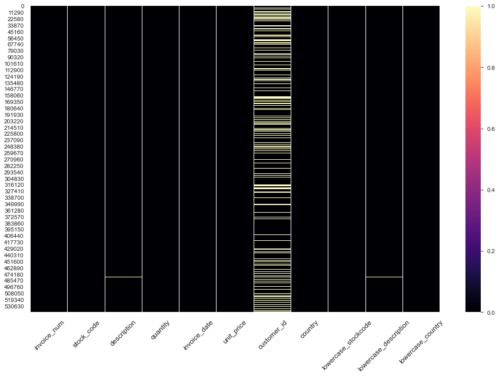

```python
# Distribuition of missing values
plt.figure(figsize=(13,9))

sns.heatmap(df.isna(), cmap='magma')

plt.xticks(rotation=45, fontsize=12)

plt.tight_layout()
```

There is no problem in keeping fields that we won't do calculations as "object", such as: invoice_num and stock_code. There are missing values in customer_id, but I will keep it this way for now. I will convert customer_id to string ("object").

```python
# We don't need ".0" in the end of the customer_id values
df.loc[~df['customer_id'].isna(), 'customer_id'] = df.loc[
                                                          ~df['customer_id'].isna(), 'customer_id'
                                                         ].apply(lambda ID: str(ID)[:-2])
```

```python
df['customer_id'].value_counts()
```

```
17841    7983
14911    5903
14096    5128
12748    4642
14606    2782
         ...
17443       1
16428       1
14119       1
14424       1
13185       1
Name: customer_id, Length: 4372, dtype: int64
```

```python
df.head()
```

|  | invoice_num | stock_code | description | quantity | invoice_date | unit_price | customer_id | country | lowercase_stockcode | lowercase_description | lowercase_country |
| --- | --- | --- | --- | --- | --- | --- | --- | --- | --- | --- | --- |
| 0 | 536365 | 85123A | WHITE HANGING HEART T-LIGHT HOLDER | 6 | 12/1/2010 8:26 | 2.55 | 17850 | United Kingdom | 85123a | white hanging heart t-light holder | united kingdom |
| 1 | 536365 | 71053 | WHITE METAL LANTERN | 6 | 12/1/2010 8:26 | 3.39 | 17850 | United Kingdom | 71053 | white metal lantern | united kingdom |
| 2 | 536365 | 84406B | CREAM CUPID HEARTS COAT HANGER | 8 | 12/1/2010 8:26 | 2.75 | 17850 | United Kingdom | 84406b | cream cupid hearts coat hanger | united kingdom |
| 3 | 536365 | 84029G | KNITTED UNION FLAG HOT WATER BOTTLE | 6 | 12/1/2010 8:26 | 3.39 | 17850 | United Kingdom | 84029g | knitted union flag hot water bottle | united kingdom |
| 4 | 536365 | 84029E | RED WOOLLY HOTTIE WHITE HEART. | 6 | 12/1/2010 8:26 | 3.39 | 17850 | United Kingdom | 84029e | red woolly hottie white heart. | united kingdom |

The next step is to transform invoice_date to "datetime".

```python
df['invoice_date'] = pd.to_datetime(df['invoice_date'])
```

```python
df.info()
```

```
<class 'pandas.core.frame.DataFrame'>
RangeIndex: 541909 entries, 0 to 541908
Data columns (total 11 columns):
 #   Column                 Non-Null Count   Dtype
---  ------                 --------------   -----
 0   invoice_num            541909 non-null  object
 1   stock_code             541909 non-null  object
 2   description            540455 non-null  object
 3   quantity               541909 non-null  int64
 4   invoice_date           541909 non-null  datetime64[ns]
 5   unit_price             541909 non-null  float64
 6   customer_id            406829 non-null  object
 7   country                541909 non-null  object
 8   lowercase_stockcode    541909 non-null  object
 9   lowercase_description  540455 non-null  object
 10  lowercase_country      541909 non-null  object
dtypes: datetime64[ns](1), float64(1), int64(1), object(8)
memory usage: 45.5+ MB
```

I will split the InvoiceDate column into: Year, Month, WeekDay, Hour and YearMonth. This way, we can group our data however we want based on any time analysis.

```python
df['year'] = df['invoice_date'].apply(lambda time: time.year)

df['month'] = df['invoice_date'].apply(lambda time: time.month)

df['month_day'] = df['invoice_date'].apply(lambda time: time.day)

df['week_day'] = df['invoice_date'].apply(lambda time: time.weekday())

df['hour'] = df['invoice_date'].apply(lambda date: date.hour)

# zfill(2) is used to fill the string with zeros until it is 2 characters long.
df['year_month'] = df['invoice_date'].apply(lambda time: str(time.year) + str(time.month).zfill(2))
```

```python
df.head()
```

|  | invoice_num | stock_code | description | quantity | invoice_date | unit_price | customer_id | country | lowercase_stockcode | lowercase_description | lowercase_country | year | month | month_day | week_day | hour | year_month |
| --- | --- | --- | --- | --- | --- | --- | --- | --- | --- | --- | --- | --- | --- | --- | --- | --- | --- |
| 0 | 536365 | 85123A | WHITE HANGING HEART T-LIGHT HOLDER | 6 | 2010-12-01 08:26:00 | 2.55 | 17850 | United Kingdom | 85123a | white hanging heart t-light holder | united kingdom | 2010 | 12 | 1 | 2 | 8 | 201012 |
| 1 | 536365 | 71053 | WHITE METAL LANTERN | 6 | 2010-12-01 08:26:00 | 3.39 | 17850 | United Kingdom | 71053 | white metal lantern | united kingdom | 2010 | 12 | 1 | 2 | 8 | 201012 |
| 2 | 536365 | 84406B | CREAM CUPID HEARTS COAT HANGER | 8 | 2010-12-01 08:26:00 | 2.75 | 17850 | United Kingdom | 84406b | cream cupid hearts coat hanger | united kingdom | 2010 | 12 | 1 | 2 | 8 | 201012 |
| 3 | 536365 | 84029G | KNITTED UNION FLAG HOT WATER BOTTLE | 6 | 2010-12-01 08:26:00 | 3.39 | 17850 | United Kingdom | 84029g | knitted union flag hot water bottle | united kingdom | 2010 | 12 | 1 | 2 | 8 | 201012 |
| 4 | 536365 | 84029E | RED WOOLLY HOTTIE WHITE HEART. | 6 | 2010-12-01 08:26:00 | 3.39 | 17850 | United Kingdom | 84029e | red woolly hottie white heart. | united kingdom | 2010 | 12 | 1 | 2 | 8 | 201012 |

We have quantity and unit_price, but we don't have the amount spent on each line. Creating the amount_spent column will make it easier to analyse revenue.

```python
df['amount_spent'] = df['quantity'] * df['unit_price']
```

Taking a look at missing values...

```python
df.isna().sum().sort_values(ascending=False)
```

```
customer_id              135080
description                1454
lowercase_description      1454
amount_spent                  0
country                       0
stock_code                    0
quantity                      0
invoice_date                  0
unit_price                    0
lowercase_stockcode           0
year_month                    0
lowercase_country             0
year                          0
month                         0
month_day                     0
week_day                      0
hour                          0
invoice_num                   0
dtype: int64
```

Perhaps, there are non-numeric fields with missing values and it did not appear in our previous analysis. Missing values can appear in strange ways, such as "", "na", "nan" and "null" strings.

```python
nullsdict = {}
nulls_vec = ['', 'na', 'nan', 'null']

for col in df.columns:
    str_nan = df.loc[~df[col].isna(), col].apply(lambda row: row in nulls_vec)
    real_nan = df[col].isna()

    nullsdict.update({col:{'str_nan':sum(str_nan),
                           'real_nan':sum(real_nan)}})

pd.DataFrame(nullsdict).T
```

|  | str_nan | real_nan |
| --- | --- | --- |
| invoice_num | 0 | 0 |
| stock_code | 0 | 0 |
| description | 0 | 1454 |
| quantity | 0 | 0 |
| invoice_date | 0 | 0 |
| unit_price | 0 | 0 |
| customer_id | 0 | 135080 |
| country | 0 | 0 |
| lowercase_stockcode | 0 | 0 |
| lowercase_description | 0 | 1454 |
| lowercase_country | 0 | 0 |
| year | 0 | 0 |
| month | 0 | 0 |
| month_day | 0 | 0 |
| week_day | 0 | 0 |
| hour | 0 | 0 |
| year_month | 0 | 0 |
| amount_spent | 0 | 0 |

We could erase the NaN values, but it will damage the sum of the revenue.

There is nothing we can do about the customer_id's missing values for now. I will analyse description column in the Exploratory Data Analysis section.

## 2) Exploratory Data Analysis (EDA)

In Data Preparation section it was possible to observe missing values in lowercase_description column. Let's take an overview of the products.

```python
products = df[['lowercase_stockcode', 'lowercase_description']].drop_duplicates()
products.head()
```

|  | lowercase_stockcode | lowercase_description |
| --- | --- | --- |
| 0 | 85123a | white hanging heart t-light holder |
| 1 | 71053 | white metal lantern |
| 2 | 84406b | cream cupid hearts coat hanger |
| 3 | 84029g | knitted union flag hot water bottle |
| 4 | 84029e | red woolly hottie white heart. |

```python
products['lowercase_stockcode'].value_counts()
```

```
20713     8
23084     8
21830     7
85175     7
23131     6
         ..
23368     1
84661b    1
21908     1
20763     1
90001d    1
Name: lowercase_stockcode, Length: 3958, dtype: int64
```

There is more than one description for the same product. Looking at the product with the stock code equal to 20713...

```python
products[products['lowercase_stockcode'] == '20713']
```

|  | lowercase_stockcode | lowercase_description |
| --- | --- | --- |
| 522 | 20713 | jumbo bag owls |
| 136272 | 20713 | NaN |
| 263884 | 20713 | wrongly marked. 23343 in box |
| 380688 | 20713 | wrongly coded-23343 |
| 403534 | 20713 | found |
| 415582 | 20713 | wrongly marked 23343 |
| 420390 | 20713 | marked as 23343 |
| 422750 | 20713 | wrongly coded 23343 |

The product with stock_code equal to 20713 actually is "jumbo bag owls". There are missing values, product incorrectly marked as 23343 and found(?). Regardless, we can assume the revenue amount is correct, so we will not change any description and unit price.

```python
products['lowercase_stockcode'].map(len).value_counts()
```

```
5     4186
6     1405
8       17
12       9
1        4
4        4
7        3
9        3
3        2
2        2
Name: lowercase_stockcode, dtype: int64
```

According to the source, if the code starts with letter "C", it indicates a cancellation.

There are stock_code with different lengths.

```python
# stock_code with 6 characters
products[products['lowercase_stockcode'].map(len) == 6].head()
```

|  | lowercase_stockcode | lowercase_description |
| --- | --- | --- |
| 0 | 85123a | white hanging heart t-light holder |
| 2 | 84406b | cream cupid hearts coat hanger |
| 3 | 84029g | knitted union flag hot water bottle |
| 4 | 84029e | red woolly hottie white heart. |
| 60 | 82494l | wooden frame antique white |

```python
# stock_code with 5 characters
products[products['lowercase_stockcode'].map(len) == 5].head()
```

|  | lowercase_stockcode | lowercase_description |
| --- | --- | --- |
| 1 | 71053 | white metal lantern |
| 5 | 22752 | set 7 babushka nesting boxes |
| 6 | 21730 | glass star frosted t-light holder |
| 7 | 22633 | hand warmer union jack |
| 8 | 22632 | hand warmer red polka dot |

It seems that stock_code values represented with 6 or 5 characters are standard sales.

```python
products['lowercase_stockcode'].map(len).value_counts().index
```

```
Int64Index([5, 6, 8, 12, 1, 4, 7, 9, 3, 2], dtype='int64')
```

```python
# Create a dataframe with stock_code descriptions
def desc_stockcode(prod):

    # stock_code lengths different from 5 and 6
    stockcode_len = [8, 12, 1, 7, 4, 9, 3, 2]

    stockcode_len = sorted(stockcode_len)

    df_stockcode = (prod[prod['lowercase_stockcode'].map(len) == stockcode_len[0]])

    for length in stockcode_len[1:]:
        df_stockcode = pd.concat([df_stockcode,
                                  prod[prod['lowercase_stockcode'].map(len) == length]],
                                  ignore_index=True)

    return df_stockcode

desc_stockcode(products)
```

|  | lowercase_stockcode | lowercase_description |
| --- | --- | --- |
| 0 | d | discount |
| 1 | m | manual |
| 2 | s | samples |
| 3 | b | adjust bad debt |
| 4 | c2 | carriage |
| 5 | c2 | NaN |
| 6 | dot | dotcom postage |
| 7 | dot | NaN |
| 8 | post | postage |
| 9 | post | NaN |
| 10 | pads | pads to match all cushions |
| 11 | cruk | cruk commission |
| 12 | 15056bl | edwardian parasol black |
| 13 | 79323gr | unsaleable, destroyed. |
| 14 | 79323lp | unsaleable, destroyed. |
| 15 | dcgs0076 | sunjar led night night light |
| 16 | dcgs0003 | boxed glass ashtray |
| 17 | dcgs0070 | camouflage dog collar |
| 18 | dcgs0055 | NaN |
| 19 | dcgs0072 | NaN |
| 20 | dcgs0074 | NaN |
| 21 | dcgs0069 | ooh la la dogs collar |
| 22 | dcgs0057 | NaN |
| 23 | dcgssboy | boys party bag |
| 24 | dcgs0004 | haynes camper shoulder bag |
| 25 | dcgs0073 | ebay |
| 26 | dcgs0071 | NaN |
| 27 | dcgs0070 | NaN |
| 28 | dcgs0069 | ebay |
| 29 | dcgs0068 | ebay |
| 30 | dcgs0067 | ebay |
| 31 | dcgs0003 | ebay |
| 32 | amazonfee | amazon fee |
| 33 | dcgssgirl | girls party bag |
| 34 | dcgs0066p | NaN |
| 35 | bank charges | bank charges |
| 36 | gift_0001_40 | dotcomgiftshop gift voucher £40.00 |
| 37 | gift_0001_50 | dotcomgiftshop gift voucher £50.00 |
| 38 | gift_0001_30 | dotcomgiftshop gift voucher £30.00 |
| 39 | gift_0001_20 | dotcomgiftshop gift voucher £20.00 |
| 40 | gift_0001_10 | dotcomgiftshop gift voucher £10.00 |
| 41 | gift_0001_20 | to push order througha s stock was |
| 42 | gift_0001_30 | NaN |
| 43 | gift_0001_10 | NaN |

Analysing the previous dataframe, stock_code can represent special events as discounts, bad debt and gift vouchers.

```python
df.describe()
```

|  | quantity | unit_price | year | month | month_day | week_day | hour | amount_spent |
| --- | --- | --- | --- | --- | --- | --- | --- | --- |
| count | 541909.000000 | 541909.000000 | 541909.000000 | 541909.000000 | 541909.000000 | 541909.000000 | 541909.000000 | 541909.000000 |
| mean | 9.552250 | 4.611114 | 2010.921609 | 7.553128 | 15.023096 | 2.431277 | 13.078729 | 17.987795 |
| std | 218.081158 | 96.759853 | 0.268787 | 3.509055 | 8.664063 | 1.844709 | 2.443270 | 378.810824 |
| min | -80995.000000 | -11062.060000 | 2010.000000 | 1.000000 | 1.000000 | 0.000000 | 6.000000 | -168469.600000 |
| 25% | 1.000000 | 1.250000 | 2011.000000 | 5.000000 | 7.000000 | 1.000000 | 11.000000 | 3.400000 |
| 50% | 3.000000 | 2.080000 | 2011.000000 | 8.000000 | 15.000000 | 2.000000 | 13.000000 | 9.750000 |
| 75% | 10.000000 | 4.130000 | 2011.000000 | 11.000000 | 22.000000 | 4.000000 | 15.000000 | 17.400000 |
| max | 80995.000000 | 38970.000000 | 2011.000000 | 12.000000 | 31.000000 | 6.000000 | 20.000000 | 168469.600000 |

There are negative values in quantity and unit_price.

```python
len(df[(df['quantity'] < 0)])
```

```
10624
```

```python
len(df[(df['unit_price'] < 0)])
```

```
2
```

There are 10624 negative values in quantity and only 2 in unit_price. I will explore and find the meaning of these values.

```python
# Starting with unit_price, because there are only 2 negative values.
df[(df['unit_price'] < 0)]
```

|  | invoice_num | stock_code | description | quantity | invoice_date | unit_price | customer_id | country | lowercase_stockcode | lowercase_description | lowercase_country | year | month | month_day | week_day | hour | year_month | amount_spent |
| --- | --- | --- | --- | --- | --- | --- | --- | --- | --- | --- | --- | --- | --- | --- | --- | --- | --- | --- |
| 299983 | A563186 | B | Adjust bad debt | 1 | 2011-08-12 14:51:00 | -11062.06 | NaN | United Kingdom | b | adjust bad debt | united kingdom | 2011 | 8 | 12 | 4 | 14 | 201108 | -11062.06 |
| 299984 | A563187 | B | Adjust bad debt | 1 | 2011-08-12 14:52:00 | -11062.06 | NaN | United Kingdom | b | adjust bad debt | united kingdom | 2011 | 8 | 12 | 4 | 14 | 201108 | -11062.06 |

Negative unit_price values are bad debt.

```python
# Checking negative quantity
df[(df['quantity'] < 0)]
```

|  | invoice_num | stock_code | description | quantity | invoice_date | unit_price | customer_id | country | lowercase_stockcode | lowercase_description | lowercase_country | year | month | month_day | week_day | hour | year_month | amount_spent |
| --- | --- | --- | --- | --- | --- | --- | --- | --- | --- | --- | --- | --- | --- | --- | --- | --- | --- | --- |
| 141 | C536379 | D | Discount | -1 | 2010-12-01 09:41:00 | 27.50 | 14527 | United Kingdom | d | discount | united kingdom | 2010 | 12 | 1 | 2 | 9 | 201012 | -27.50 |
| 154 | C536383 | 35004C | SET OF 3 COLOURED FLYING DUCKS | -1 | 2010-12-01 09:49:00 | 4.65 | 15311 | United Kingdom | 35004c | set of 3 coloured flying ducks | united kingdom | 2010 | 12 | 1 | 2 | 9 | 201012 | -4.65 |
| 235 | C536391 | 22556 | PLASTERS IN TIN CIRCUS PARADE | -12 | 2010-12-01 10:24:00 | 1.65 | 17548 | United Kingdom | 22556 | plasters in tin circus parade | united kingdom | 2010 | 12 | 1 | 2 | 10 | 201012 | -19.80 |
| 236 | C536391 | 21984 | PACK OF 12 PINK PAISLEY TISSUES | -24 | 2010-12-01 10:24:00 | 0.29 | 17548 | United Kingdom | 21984 | pack of 12 pink paisley tissues | united kingdom | 2010 | 12 | 1 | 2 | 10 | 201012 | -6.96 |
| 237 | C536391 | 21983 | PACK OF 12 BLUE PAISLEY TISSUES | -24 | 2010-12-01 10:24:00 | 0.29 | 17548 | United Kingdom | 21983 | pack of 12 blue paisley tissues | united kingdom | 2010 | 12 | 1 | 2 | 10 | 201012 | -6.96 |
| ... | ... | ... | ... | ... | ... | ... | ... | ... | ... | ... | ... | ... | ... | ... | ... | ... | ... | ... |
| 540449 | C581490 | 23144 | ZINC T-LIGHT HOLDER STARS SMALL | -11 | 2011-12-09 09:57:00 | 0.83 | 14397 | United Kingdom | 23144 | zinc t-light holder stars small | united kingdom | 2011 | 12 | 9 | 4 | 9 | 201112 | -9.13 |
| 541541 | C581499 | M | Manual | -1 | 2011-12-09 10:28:00 | 224.69 | 15498 | United Kingdom | m | manual | united kingdom | 2011 | 12 | 9 | 4 | 10 | 201112 | -224.69 |
| 541715 | C581568 | 21258 | VICTORIAN SEWING BOX LARGE | -5 | 2011-12-09 11:57:00 | 10.95 | 15311 | United Kingdom | 21258 | victorian sewing box large | united kingdom | 2011 | 12 | 9 | 4 | 11 | 201112 | -54.75 |
| 541716 | C581569 | 84978 | HANGING HEART JAR T-LIGHT HOLDER | -1 | 2011-12-09 11:58:00 | 1.25 | 17315 | United Kingdom | 84978 | hanging heart jar t-light holder | united kingdom | 2011 | 12 | 9 | 4 | 11 | 201112 | -1.25 |
| 541717 | C581569 | 20979 | 36 PENCILS TUBE RED RETROSPOT | -5 | 2011-12-09 11:58:00 | 1.25 | 17315 | United Kingdom | 20979 | 36 pencils tube red retrospot | united kingdom | 2011 | 12 | 9 | 4 | 11 | 201112 | -6.25 |

10624 rows × 18 columns

```python
# Checking invoice_num starting character.
df[(df['quantity'] < 0)]['invoice_num'].apply(lambda invoice: invoice[0]).value_counts()
```

```
C    9288
5    1336
Name: invoice_num, dtype: int64
```

```python
df[(df['quantity'] < 0)].sort_values('invoice_num')
```

|  | invoice_num | stock_code | description | quantity | invoice_date | unit_price | customer_id | country | lowercase_stockcode | lowercase_description | lowercase_country | year | month | month_day | week_day | hour | year_month | amount_spent |
| --- | --- | --- | --- | --- | --- | --- | --- | --- | --- | --- | --- | --- | --- | --- | --- | --- | --- | --- |
| 2406 | 536589 | 21777 | NaN | -10 | 2010-12-01 16:50:00 | 0.00 | NaN | United Kingdom | 21777 | NaN | united kingdom | 2010 | 12 | 1 | 2 | 16 | 201012 | -0.00 |
| 4347 | 536764 | 84952C | NaN | -38 | 2010-12-02 14:42:00 | 0.00 | NaN | United Kingdom | 84952c | NaN | united kingdom | 2010 | 12 | 2 | 3 | 14 | 201012 | -0.00 |
| 7188 | 536996 | 22712 | NaN | -20 | 2010-12-03 15:30:00 | 0.00 | NaN | United Kingdom | 22712 | NaN | united kingdom | 2010 | 12 | 3 | 4 | 15 | 201012 | -0.00 |
| 7189 | 536997 | 22028 | NaN | -20 | 2010-12-03 15:30:00 | 0.00 | NaN | United Kingdom | 22028 | NaN | united kingdom | 2010 | 12 | 3 | 4 | 15 | 201012 | -0.00 |
| 7190 | 536998 | 85067 | NaN | -6 | 2010-12-03 15:30:00 | 0.00 | NaN | United Kingdom | 85067 | NaN | united kingdom | 2010 | 12 | 3 | 4 | 15 | 201012 | -0.00 |
| ... | ... | ... | ... | ... | ... | ... | ... | ... | ... | ... | ... | ... | ... | ... | ... | ... | ... | ... |
| 540449 | C581490 | 23144 | ZINC T-LIGHT HOLDER STARS SMALL | -11 | 2011-12-09 09:57:00 | 0.83 | 14397 | United Kingdom | 23144 | zinc t-light holder stars small | united kingdom | 2011 | 12 | 9 | 4 | 9 | 201112 | -9.13 |
| 541541 | C581499 | M | Manual | -1 | 2011-12-09 10:28:00 | 224.69 | 15498 | United Kingdom | m | manual | united kingdom | 2011 | 12 | 9 | 4 | 10 | 201112 | -224.69 |
| 541715 | C581568 | 21258 | VICTORIAN SEWING BOX LARGE | -5 | 2011-12-09 11:57:00 | 10.95 | 15311 | United Kingdom | 21258 | victorian sewing box large | united kingdom | 2011 | 12 | 9 | 4 | 11 | 201112 | -54.75 |
| 541716 | C581569 | 84978 | HANGING HEART JAR T-LIGHT HOLDER | -1 | 2011-12-09 11:58:00 | 1.25 | 17315 | United Kingdom | 84978 | hanging heart jar t-light holder | united kingdom | 2011 | 12 | 9 | 4 | 11 | 201112 | -1.25 |
| 541717 | C581569 | 20979 | 36 PENCILS TUBE RED RETROSPOT | -5 | 2011-12-09 11:58:00 | 1.25 | 17315 | United Kingdom | 20979 | 36 pencils tube red retrospot | united kingdom | 2011 | 12 | 9 | 4 | 11 | 201112 | -6.25 |

10624 rows × 18 columns

```python
# How many sales had unit_price equal to 0?
sum(df['unit_price'] == 0)
```

```
2515
```

```python
# How many invoice_num codes start with "5"?
sum(df[df['unit_price'] == 0]['invoice_num'].apply(lambda invoice: invoice[0] == '5'))
```

```
2515
```

All invoices with free itens have invoice_num starting with "5"

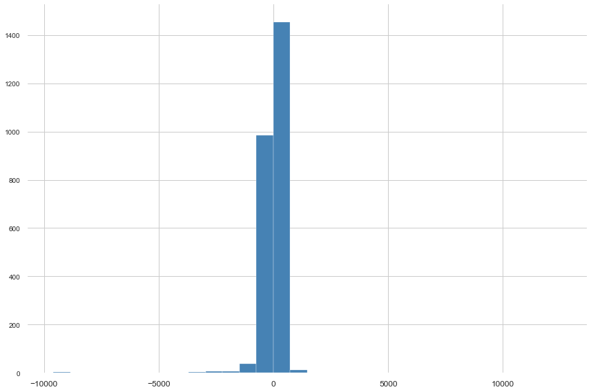

```python
# Analysing unit_price equal 0
plt.figure(figsize=(12,8))
df[df['unit_price'] == 0]['quantity'].hist(bins=30, color='steelblue')

plt.xticks(fontsize=12)
plt.tight_layout()
```

```python
# Descriptions of "free items" with positive quantity
df[(df['quantity'] > 0) & (df['unit_price'] == 0)]['lowercase_description'].value_counts()
```

```
check                                  39
found                                  34
amazon                                 18
adjustment                             16
french blue metal door sign 1           9
                                       ..
set of 2 trays home sweet home          1
christmas pudding trinket pot           1
fba                                     1
fridge magnets les enfants assorted     1
childs garden fork pink                 1
Name: lowercase_description, Length: 241, dtype: int64
```

```python
# Descriptions of "free items" with negative quantity
df[(df['quantity'] < 0) & (df['unit_price'] == 0)]['lowercase_description'].value_counts()
```

```
check                                  123
damaged                                 57
damages                                 46
?                                       41
sold as set on dotcom                   20
                                      ...
oops ! adjustment                        1
sold in set?                             1
incorrectly credited c550456 see 47      1
lost??                                   1
damaged stock                            1
Name: lowercase_description, Length: 127, dtype: int64
```

There are positive and negative quantity values for invoices with unit_price equal to 0. Some of them are damaged or from display as we can see. Perhaps some are free items for promotions or events.

Now that we know our data set better, let's do some visualization and answer some questions.

### 2.1) How many orders for each country?

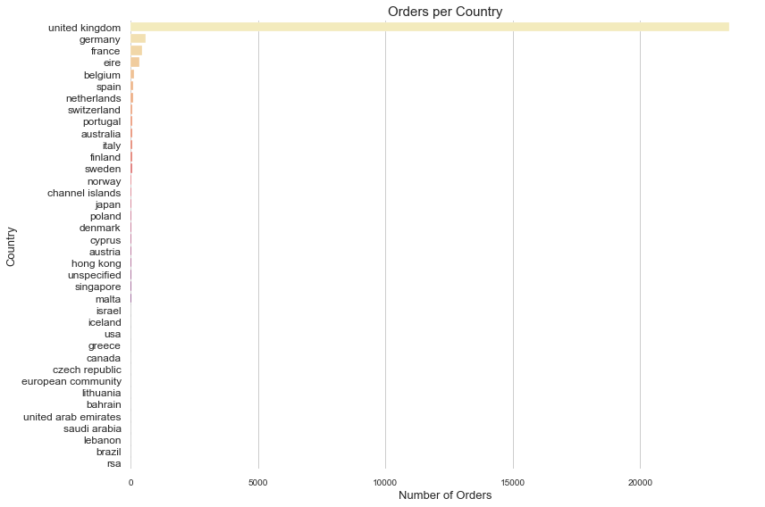

```python
plt.figure(figsize=(12,8))

ax = df.groupby('invoice_num')['lowercase_country'].unique().value_counts()

# Removing the index brackets
ax.index = [index[0] for index in ax.index]

sns.barplot(x=ax, y=ax.index, palette='magma_r', orient='h')

plt.title('Orders per Country', fontsize=15)
plt.xlabel('Number of Orders', fontsize=13)
plt.ylabel('Country', fontsize=13)

plt.yticks(fontsize=12)
plt.tight_layout()
```

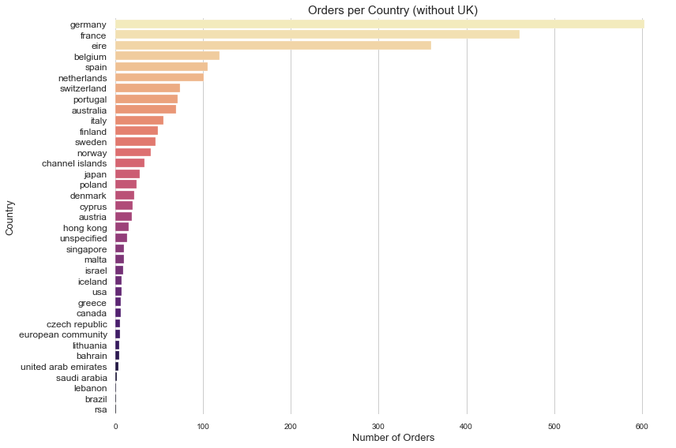

```python
plt.figure(figsize=(12,8))

# UK stands out too much on the chart
ax = df.groupby('invoice_num')['lowercase_country'].unique().value_counts().iloc[1:]

# Removing the index brackets
ax.index = [index[0] for index in ax.index]

sns.barplot(x=ax, y=ax.index, palette='magma_r', orient='h')

plt.title('Orders per Country (without UK)', fontsize=15)
plt.xlabel('Number of Orders', fontsize=13)
plt.ylabel('Country', fontsize=13)

plt.yticks(fontsize=12)
plt.tight_layout()
```

### 2.2) How much money did each country spent?

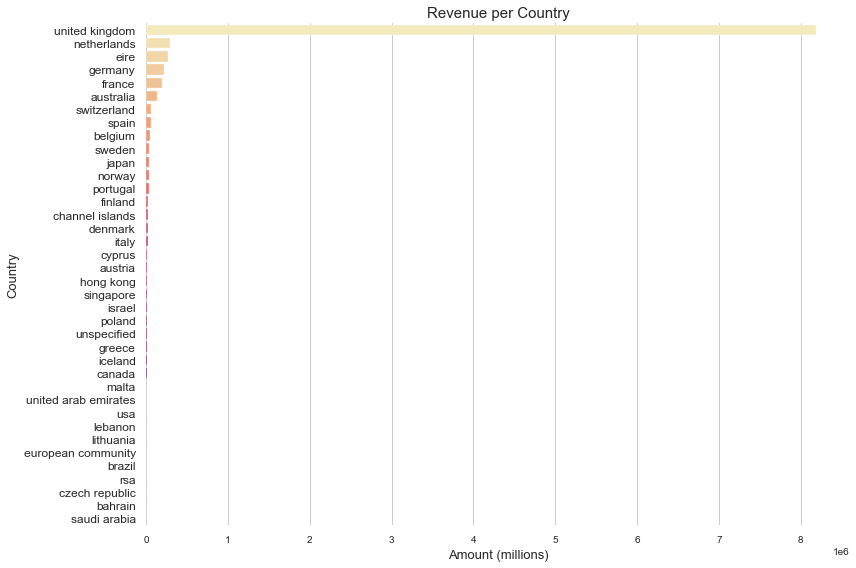

```python
plt.figure(figsize=(12,8))

ax = df.groupby('lowercase_country').sum()['amount_spent'].sort_values(ascending=False)

sns.barplot(x=ax, y=ax.index, palette='magma_r', orient='h')

plt.title('Revenue per Country', fontsize=15)
plt.xlabel('Amount (millions)', fontsize=13)
plt.ylabel('Country', fontsize=13)

plt.yticks(fontsize=12)
plt.tight_layout()
```

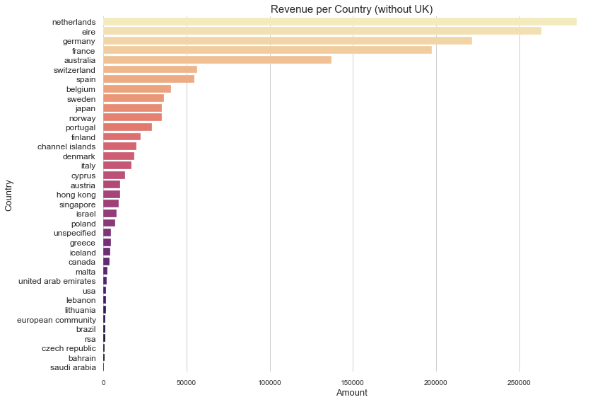

```python
plt.figure(figsize=(12,8))

# UK stands out too much on the chart
ax = df.groupby('lowercase_country').sum()['amount_spent'].sort_values(ascending=False).iloc[1:]

sns.barplot(x=ax, y=ax.index, palette='magma_r', orient='h')

plt.title('Revenue per Country (without UK)', fontsize=15)
plt.xlabel('Amount', fontsize=13)
plt.ylabel('Country', fontsize=13)

plt.yticks(fontsize=12)
plt.tight_layout()
```

This simple analysis shows that we have two important points of view:

- Look at the big picture
- Explore UK sales and separate outside

### 2.3) How were sales over the months?

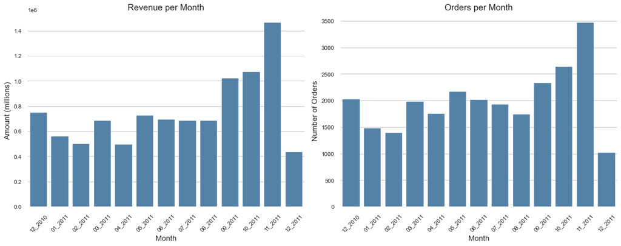

```python
fig, axes = plt.subplots(1, 2, figsize=(15, 6))

# Revenue per Month
ax = df.groupby('year_month').sum()['amount_spent']

sns.barplot(x=ax.index, y=ax, color='steelblue', ax=axes[0])

axes[0].set_title('Revenue per Month', fontsize=15)
axes[0].set_xlabel('Month', fontsize=13)
axes[0].set_ylabel('Amount (millions)', fontsize=13)

label = df['year_month'].apply(lambda date: date[4:] + '_' + date[:4]).unique()

axes[0].set_xticklabels(label, rotation=45)

# Orders x Month
ax = df.groupby('invoice_num')['year_month'].unique().value_counts().sort_index()

# Removing the index brackets
ax.index = [index[0] for index in ax.index]

sns.barplot(x=ax.index, y=ax, color='steelblue', ax=axes[1])

axes[1].set_title('Orders per Month', fontsize=15)
axes[1].set_xlabel('Month', fontsize=13)
axes[1].set_ylabel('Number of Orders', fontsize=13)

axes[1].set_xticklabels(label, rotation=45)

plt.tight_layout()
```

Remember that sales occurred between 01/12/2010 and 09/12/2011. December 2011 sales go through the 9th.  
Although the behavior of revenue and orders per month tends to be similar, we can see that the average amount spent on each order per month is different. This will be discussed in the Average Ticket section.  
January, February and April sales were the worst, except for December 2011. On the other hand, September, October and November were the best sales, in these months there is a growing demand for Christmas gifts and wholesalers are preparing for Black Friday (last Friday in November).

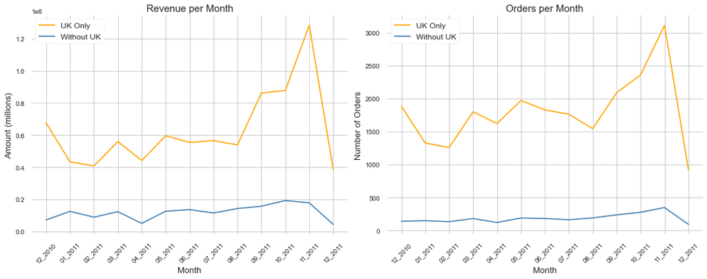

```python
# Comparing UK sales to sales outside UK
fig, axes = plt.subplots(1, 2, figsize=(15, 6))

# Revenue per Month (Only UK)
ax = df[
        df['lowercase_country'] == 'united kingdom'
       ].groupby('year_month').sum()['amount_spent']

sns.lineplot(x=ax.index, y=ax, color='orange', ax=axes[0])

# Revenue per Month (Without UK)
ax = df[
        df['lowercase_country'] != 'united kingdom'
       ].groupby('year_month').sum()['amount_spent']

sns.lineplot(x=ax.index, y=ax, color='steelblue', ax=axes[0])

axes[0].set_title('Revenue per Month', fontsize=15)
axes[0].set_xlabel('Month', fontsize=13)
axes[0].set_ylabel('Amount (millions)', fontsize=13)

label = df['year_month'].apply(lambda date: date[4:] + '_' + date[:4]).unique()

axes[0].set_xticklabels(label, rotation=45)

axes[0].legend(['UK Only', 'Without UK'], fontsize=12, framealpha=1)

# Orders x Month (Only UK)
ax = df[
        df['lowercase_country'] == 'united kingdom'
       ].groupby('invoice_num')['year_month'].unique().value_counts().sort_index()

# Removing the index brackets
ax.index = [index[0] for index in ax.index]

sns.lineplot(x=ax.index, y=ax, color='orange', ax=axes[1])

# Orders x Month (Without UK)
ax = df[
        df['lowercase_country'] != 'united kingdom'
       ].groupby('invoice_num')['year_month'].unique().value_counts().sort_index()

# Removing the index brackets
ax.index = [index[0] for index in ax.index]

sns.lineplot(x=ax.index, y=ax, color='steelblue', ax=axes[1])

axes[1].set_title('Orders per Month', fontsize=15)
axes[1].set_xlabel('Month', fontsize=13)
axes[1].set_ylabel('Number of Orders', fontsize=13)

axes[1].set_xticklabels(label, rotation=45)

axes[1].legend(['UK Only', 'Without UK'], fontsize=12, framealpha=1)

plt.tight_layout()
```

Sales outside UK appear to be more stable. Although the "Without UK" curve is much lower than the "UK Only", it looks smoothier over the months. Christmas demand is more pronounced for sales in the UK than for sales outside the UK.

### Average Ticket

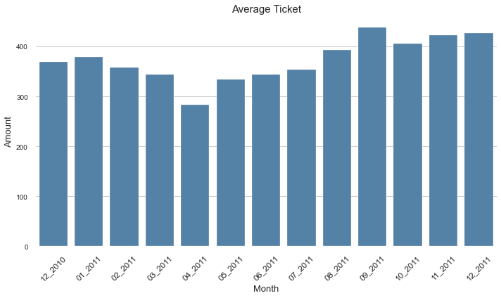

```python
plt.figure(figsize=(10,6))

ax1 = df.groupby('year_month')['amount_spent'].sum()
ax2 = df.groupby('invoice_num')['year_month'].unique().value_counts().sort_index()

# Removing the index brackets
ax2.index = [index[0] for index in ax2.index]
ax = ax1 / ax2

sns.barplot(x=ax.index, y=ax, color='steelblue')

plt.title('Average Ticket', fontsize=15)
plt.xlabel('Month', fontsize=13)
plt.ylabel('Amount', fontsize=13)

label = df['year_month'].apply(lambda date: date[4:] + '_' + date[:4]).unique()

plt.xticks(ticks=range(len(label)), labels=label, rotation=45, fontsize=12)
plt.tight_layout()
```

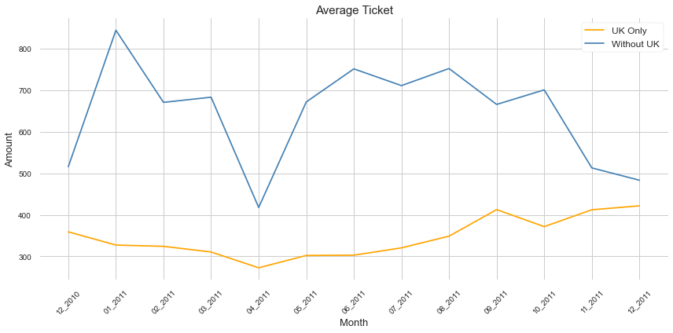

```python
# Comparing UK Average Ticket to Average Ticket outside UK
fig, axes = plt.subplots(figsize=(12, 6))

# Average Ticker (Only UK)
ax1 = df[
         df['lowercase_country'] == 'united kingdom'
        ].groupby('year_month')['amount_spent'].sum()

ax2 = df[
         df['lowercase_country'] == 'united kingdom'
        ].groupby('invoice_num')['year_month'].unique().value_counts().sort_index()

# Removing the index brackets
ax2.index = [index[0] for index in ax2.index]
ax = ax1 / ax2

sns.lineplot(x=ax.index, y=ax, color='orange', ax=axes)

label = df['year_month'].apply(lambda date: date[4:] + '_' + date[:4]).unique()

# Average Ticker (Without UK)
ax1 = df[
         df['lowercase_country'] != 'united kingdom'
        ].groupby('year_month')['amount_spent'].sum()

ax2 = df[
         df['lowercase_country'] != 'united kingdom'
        ].groupby('invoice_num')['year_month'].unique().value_counts().sort_index()

# Removing the index brackets
ax2.index = [index[0] for index in ax2.index]
ax = ax1 / ax2

sns.lineplot(x=ax.index, y=ax, color='steelblue', ax=axes)

axes.set_title('Average Ticket', fontsize=15)
axes.set_xlabel('Month', fontsize=13)
axes.set_ylabel('Amount', fontsize=13)

axes.set_xticklabels(label, rotation=45)

axes.legend(['UK Only', 'Without UK'], fontsize=12, framealpha=1)

plt.tight_layout()
```

Althongh revenue and number of orders in the UK are higher than abroad, the opposite is true for the average ticket. This indicates that the amount spent on orders outside the UK are higher.  
Looking at all the sales over the months, we can see a significant drop in April.  
There are some key dates that move retail and April is just between them:

- Frebruary: Valentine's Day
- May: Mother's Day
- June: Father's Day
- August/September: Back-to-school (most countries are in the northern hemisphere)
- October: Halloween
- November: Black Friday
- December: Christmas

### 2.4) How orders were distributed by day (of month)

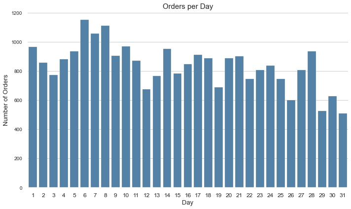

```python
plt.figure(figsize=(10,6))

ax = df.groupby('invoice_num')['month_day'].unique().value_counts().sort_index()

# Removing the index brackets
ax.index = [index[0] for index in ax.index]

sns.barplot(x=ax.index, y=ax, color='steelblue')

plt.title('Orders per Day', fontsize=15)
plt.xlabel('Day', fontsize=13)
plt.ylabel('Number of Orders', fontsize=13)

plt.xticks(fontsize=12)
plt.tight_layout()
```

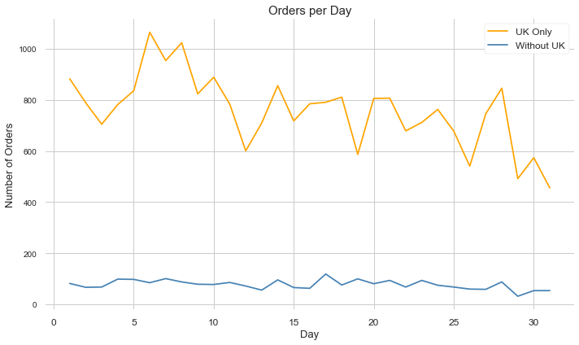

```python
# Comparing UK orders to orders outside UK per day
fig, axes = plt.subplots(figsize=(10, 6))

# Order per day (UK only)
ax = df[
        df['lowercase_country'] == 'united kingdom'
       ].groupby('invoice_num')['month_day'].unique().value_counts().sort_index()

# Removing the index brackets
ax.index = [index[0] for index in ax.index]

sns.lineplot(x=ax.index, y=ax, color='orange', ax=axes)

# Order per day (without UK)
ax = df[
        df['lowercase_country'] != 'united kingdom'
       ].groupby('invoice_num')['month_day'].unique().value_counts().sort_index()

# Removing the index brackets
ax.index = [index[0] for index in ax.index]

sns.lineplot(x=ax.index, y=ax, color='steelblue', ax=axes)

axes.set_title('Orders per Day', fontsize=15)
axes.set_xlabel('Day', fontsize=13)
axes.set_ylabel('Number of Orders', fontsize=13)

axes.tick_params(axis="x", labelsize=12)

axes.legend(['UK Only', 'Without UK'], fontsize=12, framealpha=1)

plt.tight_layout()
```

There is a substancial demand between the 5th and 10th, but it is not enough to say the trend with certainty.  
For this analysis, I will use the Polynomial Regression approach, taking the number of orders per day as a series. The goal is to plot just a trend line.

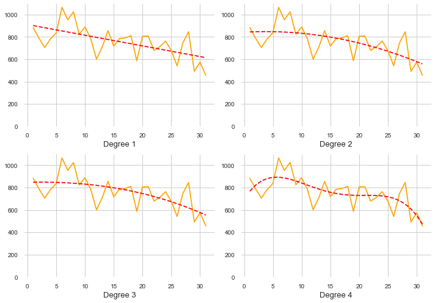

```python
fig, axes = plt.subplots(2, 2, figsize=(10, 7))

for i in range(4):

    # Where each subplot will be
    if i < 2:
        plot = (0,i)
    else:
        plot = (1,(i-2))

    # Order per day (UK only)
    y = df[
           df['lowercase_country'] == 'united kingdom'
          ].groupby('invoice_num')['month_day'].unique().value_counts().sort_index()

    # Removing the index brackets
    x = [index[0] for index in y.index]

    sns.lineplot(x=x, y=y, color='orange', ax=axes[plot])

    # transforming the data to include another axis
    x = np.array(x)
    x = x[:, np.newaxis]
    y = y[:, np.newaxis]

    polynomial_features= PolynomialFeatures(degree=(i+1))
    x_poly = polynomial_features.fit_transform(x)

    model = LinearRegression()
    model.fit(x_poly, y)
    y_poly_pred = model.predict(x_poly)

    axes[plot].plot(x, y_poly_pred, 'r--')

    axes[plot].set_xlabel('Degree ' + str(i+1), fontsize=13)
    axes[plot].set_ylabel('')

    axes[plot].set_ylim(ymin=0)

plt.tight_layout()
```

The dashed red line shows the trend. The second and third-degree are almost the same. I will use the third-degree. Higher degrees will just overfit it.

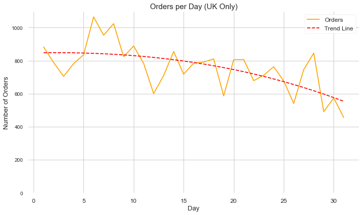

```python
fig, axes = plt.subplots(figsize=(10, 6))

# Order per day (UK only)
y = df[
       df['lowercase_country'] == 'united kingdom'
      ].groupby('invoice_num')['month_day'].unique().value_counts().sort_index()

# Removing the index brackets
x = [index[0] for index in y.index]

sns.lineplot(x=x, y=y, color='orange', ax=axes)

# transforming the data to include another axis
x = np.array(x)
x = x[:, np.newaxis]
y = y[:, np.newaxis]

polynomial_features= PolynomialFeatures(degree=3)
x_poly = polynomial_features.fit_transform(x)

model = LinearRegression()
model.fit(x_poly, y)
y_poly_pred = model.predict(x_poly)

axes.plot(x, y_poly_pred, 'r--')

axes.set_title('Orders per Day (UK Only)', fontsize=15)
axes.set_xlabel('Day', fontsize=13)
axes.set_ylabel('Number of Orders', fontsize=13)

axes.tick_params(axis="x", labelsize=12)

axes.legend(['Orders', 'Trend Line'], fontsize=12, framealpha=1)

plt.ylim(ymin=0)

plt.tight_layout()
```

In the UK, the number of orders starts high at the begining of the month and falls over the days.

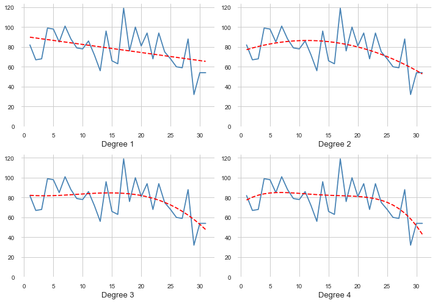

```python
fig, axes = plt.subplots(2, 2, figsize=(10, 7))

for i in range(4):

    # Where each subplot will be
    if i < 2:
        plot = (0,i)
    else:
        plot = (1,(i-2))

    # Order per day (UK only)
    y = df[
           df['lowercase_country'] != 'united kingdom'
          ].groupby('invoice_num')['month_day'].unique().value_counts().sort_index()

    # Removing the index brackets
    x = [index[0] for index in y.index]

    sns.lineplot(x=x, y=y, color='steelblue', ax=axes[plot])

    # transforming the data to include another axis
    x = np.array(x)
    x = x[:, np.newaxis]
    y = y[:, np.newaxis]

    polynomial_features= PolynomialFeatures(degree=(i+1))
    x_poly = polynomial_features.fit_transform(x)

    model = LinearRegression()
    model.fit(x_poly, y)
    y_poly_pred = model.predict(x_poly)

    axes[plot].plot(x, y_poly_pred, 'r--')

    axes[plot].set_xlabel('Degree ' + str(i+1), fontsize=13)
    axes[plot].set_ylabel('')

    axes[plot].set_ylim(ymin=0)

plt.tight_layout()
```

Third-degree fits better the number of orders per day.

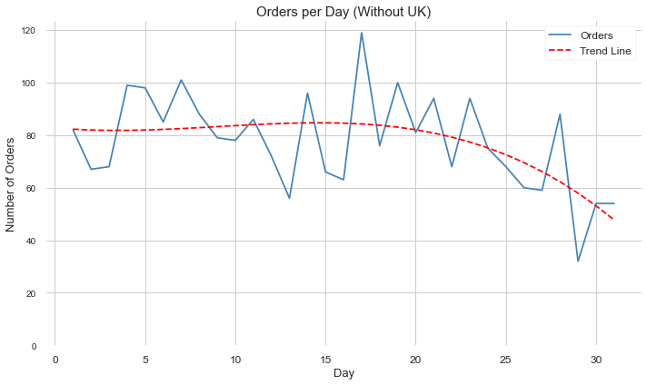

```python
fig, axes = plt.subplots(figsize=(10, 6))

# Order per day (without UK)
y = df[
       df['lowercase_country'] != 'united kingdom'
      ].groupby('invoice_num')['month_day'].unique().value_counts().sort_index()

# Removing the index brackets
x = [index[0] for index in y.index]

sns.lineplot(x=x, y=y, color='steelblue', ax=axes)

# transforming the data to include another axis
x = np.array(x)
x = x[:, np.newaxis]
y = y[:, np.newaxis]

polynomial_features= PolynomialFeatures(degree=3)
x_poly = polynomial_features.fit_transform(x)

model = LinearRegression()
model.fit(x_poly, y)
y_poly_pred = model.predict(x_poly)

axes.plot(x, y_poly_pred, 'r--')

axes.set_title('Orders per Day (Without UK)', fontsize=15)
axes.set_xlabel('Day', fontsize=13)
axes.set_ylabel('Number of Orders', fontsize=13)

axes.tick_params(axis="x", labelsize=12)

axes.legend(['Orders', 'Trend Line'], fontsize=12, framealpha=1)

plt.ylim(ymin=0)

plt.tight_layout()
```

Outside the UK, we can see that the number of orders remains stable until the 20th and then starts to fall.  
Although a third-degree polynomial cannot fully express the sales forecast, it did a good job helping us understand the chaotic behavior of orders per day.

### 2.5) How orders were distributed by day (of week):

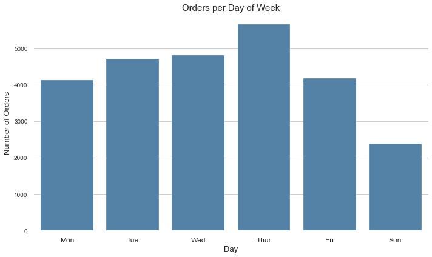

```python
plt.figure(figsize=(10,6))

ax = df.groupby('invoice_num')['week_day'].unique().value_counts().sort_index()

# Removing the index brackets
ax.index = [index[0] for index in ax.index]

sns.barplot(x=ax.index, y=ax, color='steelblue')

plt.title('Orders per Day of Week', fontsize=15)
plt.xlabel('Day', fontsize=13)
plt.ylabel('Number of Orders', fontsize=13)

# WeekDay goes from 0-Monday to 6-Sunday
label = ['Mon','Tue','Wed','Thur','Fri','Sun']
tick = range(len(label))

plt.xticks(ticks=tick, labels=label, fontsize=12)
plt.tight_layout()
```

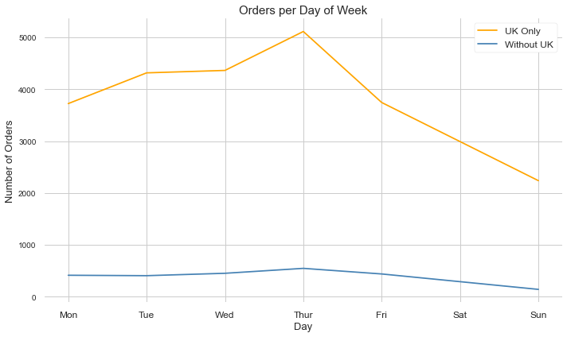

```python
# Comparing UK orders to orders outside UK per day of week
fig, axes = plt.subplots(figsize=(10, 6))

# Order per day of week (UK only)
ax = df[
        df['lowercase_country'] == 'united kingdom'
       ].groupby('invoice_num')['week_day'].unique().value_counts().sort_index()

# Removing the index brackets
ax.index = [index[0] for index in ax.index]

sns.lineplot(x=ax.index, y=ax, color='orange', ax=axes)

# Order per day of week (without UK)
ax = df[
        df['lowercase_country'] != 'united kingdom'
       ].groupby('invoice_num')['week_day'].unique().value_counts().sort_index()

# Removing the index brackets
ax.index = [index[0] for index in ax.index]

sns.lineplot(x=ax.index, y=ax, color='steelblue', ax=axes)

axes.set_title('Orders per Day of Week', fontsize=15)
axes.set_xlabel('Day', fontsize=13)
axes.set_ylabel('Number of Orders', fontsize=13)

label = ['','Mon','Tue','Wed','Thur','Fri', 'Sat', 'Sun']

axes.set_xticklabels(label, fontsize=12)

axes.legend(['UK Only', 'Without UK'], fontsize=12, framealpha=1)

plt.tight_layout()
```

The peak in the number of orders is on Thursday. Although Saturday appears on the chart, there are no recorded sales, it is just the trend line between Friday and Sunday.

### 2.6) How orders were distributed by hour?

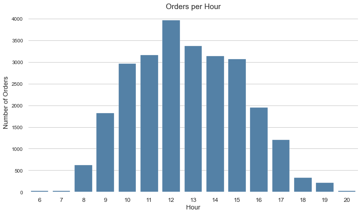

```python
plt.figure(figsize=(10,6))

ax = df.groupby('invoice_num')['hour'].unique().value_counts().iloc[:-1].sort_index()

# Removing the index brackets
ax.index = [index[0] for index in ax.index]

sns.barplot(x=ax.index, y=ax, color='steelblue')

plt.title('Orders per Hour', fontsize=15)
plt.xlabel('Hour', fontsize=13)
plt.ylabel('Number of Orders', fontsize=13)

plt.xticks(fontsize=12)
plt.tight_layout()
```

Sales are concetrated around noon. Indicates that there is a preference to buy at lunch.

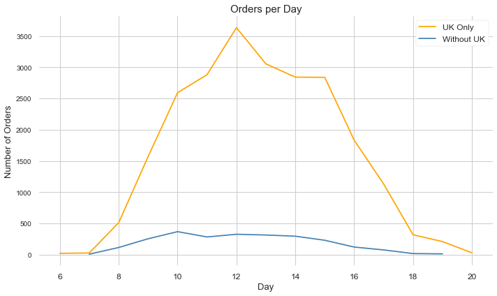

```python
# Comparing UK orders to orders outside UK per hour
fig, axes = plt.subplots(figsize=(10, 6))

# Order per hour (UK only)
ax = df[
        df['lowercase_country'] == 'united kingdom'
       ].groupby('invoice_num')['hour'].unique().value_counts().iloc[:-1].sort_index()

# Removing the index brackets
ax.index = [index[0] for index in ax.index]

sns.lineplot(x=ax.index, y=ax, color='orange', ax=axes)

# Order per hour (without UK)
ax = df[
        df['lowercase_country'] != 'united kingdom'
       ].groupby('invoice_num')['hour'].unique().value_counts().iloc[:-1].sort_index()

# Removing the index brackets
ax.index = [index[0] for index in ax.index]

sns.lineplot(x=ax.index, y=ax, color='steelblue', ax=axes)

axes.set_title('Orders per Day', fontsize=15)
axes.set_xlabel('Day', fontsize=13)
axes.set_ylabel('Number of Orders', fontsize=13)

axes.tick_params(axis="x", labelsize=12)

axes.legend(['UK Only', 'Without UK'], fontsize=12, framealpha=1)

plt.tight_layout()
```

Sales in the UK take place between 6 am and 8 pm, while external sales take place between 7 am and 7 pm.

### 2.7) What are the most common stock codes?

These are the top 20 stock codes and how much do they represent in revenue (percentage).

```python
common_codes = []

for code in df['lowercase_stockcode'].value_counts()[:20].index:

    common_codes.append((code,
                         products[
                                  (products[~products.isna()]['lowercase_stockcode'] == code)
                                 ]['lowercase_description'].iloc[0],
                         df[df['lowercase_stockcode'] == code]['amount_spent'].sum(),
                         df[df['lowercase_stockcode'] == code]['amount_spent'].sum() / df['amount_spent'].sum() * 100))


pd.DataFrame(common_codes, columns=['lowercase_stockcode', 'description', 'amount', 'percertage'])
```

|  | lowercase_stockcode | description | amount | percertage |
| --- | --- | --- | --- | --- |
| 0 | 85123a | white hanging heart t-light holder | 99846.98 | 1.024308 |
| 1 | 22423 | regency cakestand 3 tier | 164762.19 | 1.690259 |
| 2 | 85099b | jumbo bag red retrospot | 92356.03 | 0.947460 |
| 3 | 47566 | party bunting | 98302.98 | 1.008469 |
| 4 | 20725 | lunch bag red retrospot | 35187.31 | 0.360979 |
| 5 | 84879 | assorted colour bird ornament | 58959.73 | 0.604855 |
| 6 | 22720 | set of 3 cake tins pantry design | 37413.44 | 0.383816 |
| 7 | 22197 | small popcorn holder | 50987.47 | 0.523069 |
| 8 | 21212 | pack of 72 retrospot cake cases | 21059.72 | 0.216047 |
| 9 | 20727 | lunch bag black skull. | 22219.01 | 0.227940 |
| 10 | 22383 | lunch bag suki design | 22318.64 | 0.228962 |
| 11 | 22457 | natural slate heart chalkboard | 27995.36 | 0.287198 |
| 12 | 23203 | mailout | 40991.38 | 0.420522 |
| 13 | post | postage | 66230.64 | 0.679446 |
| 14 | 22386 | jumbo bag pink polkadot | 41619.66 | 0.426967 |
| 15 | 22469 | heart of wicker small | 31899.85 | 0.327254 |
| 16 | 22960 | jam making set with jars | 36116.09 | 0.370507 |
| 17 | 21931 | jumbo storage bag suki | 30167.79 | 0.309485 |
| 18 | 22086 | paper chain kit 50's christmas | 63791.94 | 0.654427 |
| 19 | 22411 | jumbo shopper vintage red paisley | 28012.48 | 0.287374 |

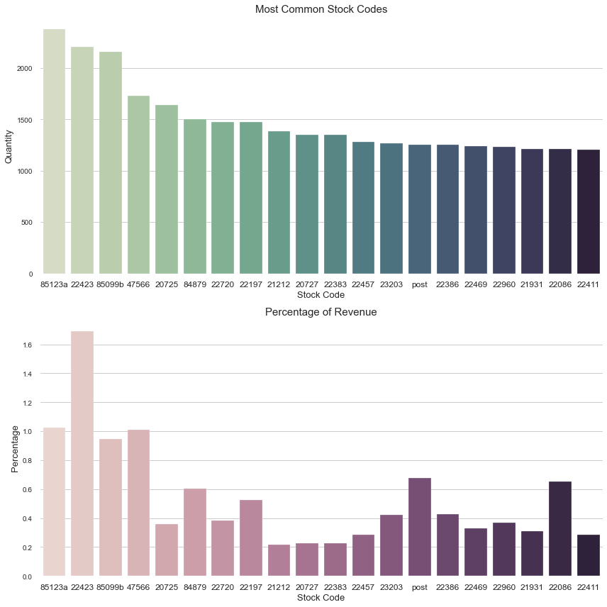

```python
fig, axes = plt.subplots(2, 1, figsize=(12, 12))

# The 20 most common stock codes
ax = df['lowercase_stockcode'].value_counts()[:20]

sns.barplot(x=ax.index, y=ax,
            palette=sns.cubehelix_palette(20, start=.5, rot=-.75),
            ax=axes[0])

axes[0].set_title('Most Common Stock Codes', fontsize=15)
axes[0].set_xlabel('Stock Code', fontsize=13)
axes[0].set_ylabel('Quantity', fontsize=13)

axes[0].tick_params(axis="x", labelsize=12)

# Percentage of revenue (20 most common stock codes)
common_codes = []

for code in df['lowercase_stockcode'].value_counts()[:20].index:

    common_codes.append((code,
                         df[df['lowercase_stockcode'] == code]['amount_spent'].sum() / df['amount_spent'].sum() * 100))


ax = pd.DataFrame(common_codes, columns=['lowercase_stockcode', 'percertage'])

sns.barplot(x='lowercase_stockcode', y='percertage', data=ax,
            palette=sns.cubehelix_palette(20),
            ax=axes[1])

axes[1].set_title('Percentage of Revenue', fontsize=15)
axes[1].set_xlabel('Stock Code', fontsize=13)
axes[1].set_ylabel('Percentage', fontsize=13)

axes[1].tick_params(axis="x", labelsize=12)

plt.tight_layout()
```

Being the most frequent does not mean necessarily represent a large part of the revenue. The product **85123A - "white hanging heart t-light holder"** is the best seller and representes practically **1.0%** of the revenue while the product **22423 - "regency cakestand 3 tier"** is the second place and represents more than **1.6%** of the revenue.

### 2.8) Which stock codes contribute the most to revenue?

The top 20 stock codes that contribute the most to revenue:

```python
top_revenue = []

for code in df.groupby(
                       'lowercase_stockcode'
                      )[
                        'amount_spent'
                       ].sum().sort_values(ascending=False)[:20].index:

    top_revenue.append((code,
                        products[
                                 (products[~products.isna()]['lowercase_stockcode'] == code)
                                ]['lowercase_description'].iloc[0],
                        df[df['lowercase_stockcode'] == code]['amount_spent'].sum(),
                        df[df['lowercase_stockcode'] == code]['amount_spent'].sum() / df['amount_spent'].sum() * 100))


pd.DataFrame(top_revenue, columns=['lowercase_stockcode', 'description', 'amount', 'percertage'])
```

|  | lowercase_stockcode | description | amount | percertage |
| --- | --- | --- | --- | --- |
| 0 | dot | dotcom postage | 206245.48 | 2.115827 |
| 1 | 22423 | regency cakestand 3 tier | 164762.19 | 1.690259 |
| 2 | 85123a | white hanging heart t-light holder | 99846.98 | 1.024308 |
| 3 | 47566 | party bunting | 98302.98 | 1.008469 |
| 4 | 85099b | jumbo bag red retrospot | 92356.03 | 0.947460 |
| 5 | 23084 | rabbit night light | 66756.59 | 0.684841 |
| 6 | post | postage | 66230.64 | 0.679446 |
| 7 | 22086 | paper chain kit 50's christmas | 63791.94 | 0.654427 |
| 8 | 84879 | assorted colour bird ornament | 58959.73 | 0.604855 |
| 9 | 79321 | chilli lights | 53768.06 | 0.551595 |
| 10 | 22502 | picnic basket wicker small | 51041.37 | 0.523622 |
| 11 | 22197 | small popcorn holder | 50987.47 | 0.523069 |
| 12 | 23298 | spotty bunting | 42700.02 | 0.438050 |
| 13 | 22386 | jumbo bag pink polkadot | 41619.66 | 0.426967 |
| 14 | 23203 | mailout | 40991.38 | 0.420522 |
| 15 | 21137 | black record cover frame | 40596.96 | 0.416475 |
| 16 | 22720 | set of 3 cake tins pantry design | 37413.44 | 0.383816 |
| 17 | 23284 | doormat keep calm and come in | 36565.39 | 0.375116 |
| 18 | 22960 | jam making set with jars | 36116.09 | 0.370507 |
| 19 | 82484 | wood black board ant white finish | 35859.27 | 0.367872 |

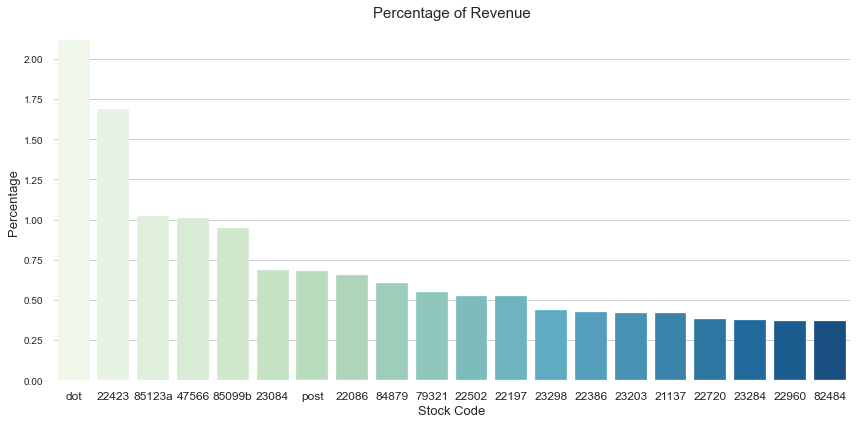

```python
plt.figure(figsize=(12,6))

# top 20 stock codes in revenue
ax = df.groupby(
                'lowercase_stockcode'
               )[
                 'amount_spent'
                ].sum().sort_values(ascending=False)[:20] / df['amount_spent'].sum() * 100

sns.barplot(x=ax.index, y=ax, palette='GnBu')

plt.title('Percentage of Revenue', fontsize=15)
plt.xlabel('Stock Code', fontsize=13)
plt.ylabel('Percentage', fontsize=13)

plt.xticks(fontsize=12)
plt.tight_layout()
```

**DOT** means **"dotcom postage"**, that is, it is not a product but a service. The real top product is the stock code **22423 - "regency cakestand 3 tier"** and stands out compared to others.

## 3) Categorizing Products

We previously performed a superficial analysis dealing with stock codes. It's time to clean up this mess, separating what is a product from other operations. In this way, it is possible to group products into categories.

### 3.1) Clearing Product Data

```python
products
```

|  | lowercase_stockcode | lowercase_description |
| --- | --- | --- |
| 0 | 85123a | white hanging heart t-light holder |
| 1 | 71053 | white metal lantern |
| 2 | 84406b | cream cupid hearts coat hanger |
| 3 | 84029g | knitted union flag hot water bottle |
| 4 | 84029e | red woolly hottie white heart. |
| ... | ... | ... |
| 536908 | 23090 | missing |
| 537621 | 85123a | cream hanging heart t-light holder |
| 538554 | 85175 | NaN |
| 538919 | 23169 | smashed |
| 540421 | 23843 | paper craft , little birdie |

5635 rows × 2 columns

Remember that we interpreted stock codes with lengths of 5 and 6 as products.

```python
# stock_code lengths different from 5 and 6
desc_stockcode(products).dropna()
```

|  | lowercase_stockcode | lowercase_description |
| --- | --- | --- |
| 0 | d | discount |
| 1 | m | manual |
| 2 | s | samples |
| 3 | b | adjust bad debt |
| 4 | c2 | carriage |
| 6 | dot | dotcom postage |
| 8 | post | postage |
| 10 | pads | pads to match all cushions |
| 11 | cruk | cruk commission |
| 12 | 15056bl | edwardian parasol black |
| 13 | 79323gr | unsaleable, destroyed. |
| 14 | 79323lp | unsaleable, destroyed. |
| 15 | dcgs0076 | sunjar led night night light |
| 16 | dcgs0003 | boxed glass ashtray |
| 17 | dcgs0070 | camouflage dog collar |
| 21 | dcgs0069 | ooh la la dogs collar |
| 23 | dcgssboy | boys party bag |
| 24 | dcgs0004 | haynes camper shoulder bag |
| 25 | dcgs0073 | ebay |
| 28 | dcgs0069 | ebay |
| 29 | dcgs0068 | ebay |
| 30 | dcgs0067 | ebay |
| 31 | dcgs0003 | ebay |
| 32 | amazonfee | amazon fee |
| 33 | dcgssgirl | girls party bag |
| 35 | bank charges | bank charges |
| 36 | gift_0001_40 | dotcomgiftshop gift voucher £40.00 |
| 37 | gift_0001_50 | dotcomgiftshop gift voucher £50.00 |
| 38 | gift_0001_30 | dotcomgiftshop gift voucher £30.00 |
| 39 | gift_0001_20 | dotcomgiftshop gift voucher £20.00 |
| 40 | gift_0001_10 | dotcomgiftshop gift voucher £10.00 |
| 41 | gift_0001_20 | to push order througha s stock was |

Of all the stock codes above, only these represent products:

- **15056bl** - edwardian parasol black
- **dcgs0076** - sunjar led night night light
- **dcgs0003** - boxed glass ashtray
- **dcgs0070** - camouflage dog collar
- **dcgs0069** - ooh la la dogs collar
- **dcgssboy** - boys party bag
- **dcgs0004** - haynes camper shoulder bag
- **dcgssgirl** - girls party bag

I will drop the remaining stock codes.

```python
products_clean = products.dropna()
products_clean
```

|  | lowercase_stockcode | lowercase_description |
| --- | --- | --- |
| 0 | 85123a | white hanging heart t-light holder |
| 1 | 71053 | white metal lantern |
| 2 | 84406b | cream cupid hearts coat hanger |
| 3 | 84029g | knitted union flag hot water bottle |
| 4 | 84029e | red woolly hottie white heart. |
| ... | ... | ... |
| 535336 | 22576 | check |
| 536908 | 23090 | missing |
| 537621 | 85123a | cream hanging heart t-light holder |
| 538919 | 23169 | smashed |
| 540421 | 23843 | paper craft , little birdie |

4675 rows × 2 columns

```python
# List of stock codes to drop (not a product)
codesToDrop = ['d', 'm', 's', 'b', 'c2', 'dot', 'post', 'pads', 'cruk',
               '79323gr', '79323lp', 'dcgs0073', 'dcgs0069', 'dcgs0068',
               'dcgs0067', 'dcgs0003', 'amazonfee', 'bank charges',
               'gift_0001_40', 'gift_0001_50', 'gift_0001_30', 'gift_0001_20',
               'gift_0001_10', 'gift_0001_20']

products_clean = products_clean[~products_clean['lowercase_stockcode'].isin(codesToDrop)]
```

```python
products_clean
```

|  | lowercase_stockcode | lowercase_description |
| --- | --- | --- |
| 0 | 85123a | white hanging heart t-light holder |
| 1 | 71053 | white metal lantern |
| 2 | 84406b | cream cupid hearts coat hanger |
| 3 | 84029g | knitted union flag hot water bottle |
| 4 | 84029e | red woolly hottie white heart. |
| ... | ... | ... |
| 535336 | 22576 | check |
| 536908 | 23090 | missing |
| 537621 | 85123a | cream hanging heart t-light holder |
| 538919 | 23169 | smashed |
| 540421 | 23843 | paper craft , little birdie |

4649 rows × 2 columns

We need to remove unnecessary things from product description before our analysis.

**Punctuation**, **color names** and **numbers** will not be very effective when we try to correlate products by their description. Suppose a product called "Action Figure: Red Swamp Monster" and another called "15cm Action Figure". Between these two descriptions what matters is the fact that they are Action Figures, not the colon, color or their size.

Removing **stopwords** will eliminate generic words that can be commom in many descriptions. **Stemming** the words will allow we to group variations of words with the same origin and meaning.

```python
# Stemming
ps = PorterStemmer()

def cleanText(text):
    # Stripping punctuation from the string
    # This performs raw string operations in C
    text = text.translate(str.maketrans('', '', string.punctuation))
    # Stripping numbers
    text = ''.join([i for i in text if not i.isdigit()])
    # Removing color names
    text = ' '.join([i for i in text.split() if(i not in CSS3_NAMES_TO_HEX)])
    text = text.strip().split()
    # Removing stopwords and stemming
    text = [ps.stem(word) for word in text if(word not in stopwords.words('english'))]

    return ' '.join(text)
```

```python
products_clean['cleanned_description'] = products_clean['lowercase_description'].apply(cleanText)
```

Tokenize allows to count how many words are in each description and search for products with a specific word.

```python
products_clean['tokenized_description'] = products_clean['cleanned_description'].apply(lambda text: text.split())
```

```python
products_clean
```

|  | lowercase_stockcode | lowercase_description | cleanned_description | tokenized_description |
| --- | --- | --- | --- | --- |
| 0 | 85123a | white hanging heart t-light holder | hang heart tlight holder | [hang, heart, tlight, holder] |
| 1 | 71053 | white metal lantern | metal lantern | [metal, lantern] |
| 2 | 84406b | cream cupid hearts coat hanger | cream cupid heart coat hanger | [cream, cupid, heart, coat, hanger] |
| 3 | 84029g | knitted union flag hot water bottle | knit union flag hot water bottl | [knit, union, flag, hot, water, bottl] |
| 4 | 84029e | red woolly hottie white heart. | woolli hotti heart | [woolli, hotti, heart] |
| ... | ... | ... | ... | ... |
| 535336 | 22576 | check | check | [check] |
| 536908 | 23090 | missing | miss | [miss] |
| 537621 | 85123a | cream hanging heart t-light holder | cream hang heart tlight holder | [cream, hang, heart, tlight, holder] |
| 538919 | 23169 | smashed | smash | [smash] |
| 540421 | 23843 | paper craft , little birdie | paper craft littl birdi | [paper, craft, littl, birdi] |

4649 rows × 4 columns

The frequency of the number of words in each description can help define what is a product and what is dirty data.

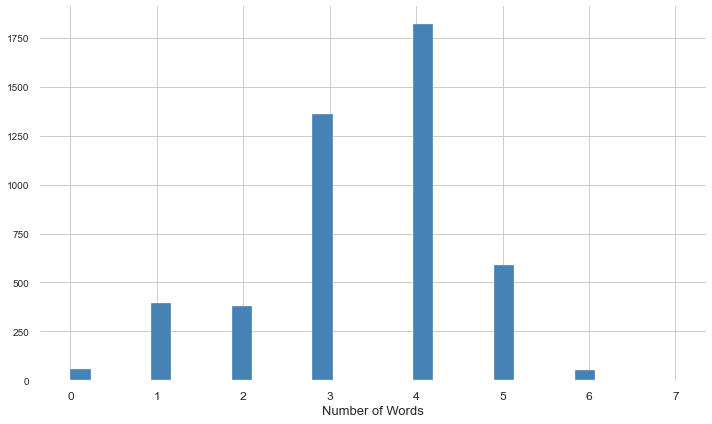

```python
plt.figure(figsize=(10,6))

products_clean['tokenized_description'].map(len).hist(bins=30, color='steelblue')

plt.xlabel('Number of Words', fontsize=13)
plt.xticks(fontsize=12)
plt.tight_layout()
```

The description pattern with 0, 1 and 2 words is a hint that there are "defective descriptions" between them.

```python
# Wordless descriptions
products_clean[
               products_clean['tokenized_description'].map(len) == 0
              ].head()
```

|  | lowercase_stockcode | lowercase_description | cleanned_description | tokenized_description |
| --- | --- | --- | --- | --- |
| 7313 | 21275 | ? |  | [] |
| 21518 | 20956 | ? |  | [] |
| 38261 | 21479 | ? |  | [] |
| 43662 | 22837 | ? |  | [] |
| 50806 | 21258 | ? |  | [] |

Wordless descriptions are just numbers and punctuation. Taking stock code **21275** at random, we can see there is a real description associated with this "noise".

```python
products_clean[products_clean['lowercase_stockcode'] == '21275']
```

|  | lowercase_stockcode | lowercase_description | cleanned_description | tokenized_description |
| --- | --- | --- | --- | --- |
| 7313 | 21275 | ? |  | [] |
| 17390 | 21275 | zinc top 2 door wooden shelf | zinc top door wooden shelf | [zinc, top, door, wooden, shelf] |

```python
# Removing wordless descriptions
products_clean = products_clean[products_clean['tokenized_description'].map(len) != 0]
```

```python
products_clean[products_clean['tokenized_description'].map(len) == 0]
```

|  | lowercase_stockcode | lowercase_description | cleanned_description | tokenized_description |
| --- | --- | --- | --- | --- |

```python
# Description with 1 word
products_clean[
               products_clean['tokenized_description'].map(len) == 1
              ].head()
```

|  | lowercase_stockcode | lowercase_description | cleanned_description | tokenized_description |
| --- | --- | --- | --- | --- |
| 144 | 21832 | chocolate calculator | calcul | [calcul] |
| 1010 | 71406c | black orange squeezer | squeezer | [squeezer] |
| 6391 | 22734 | amazon | amazon | [amazon] |
| 6392 | 22139 | amazon | amazon | [amazon] |
| 8591 | 62018 | sombrero | sombrero | [sombrero] |

```python
# Removing duplicate descriptions
products_clean[
               products_clean['tokenized_description'].map(len) == 1
              ].drop_duplicates(subset=['cleanned_description'])
```

|  | lowercase_stockcode | lowercase_description | cleanned_description | tokenized_description |
| --- | --- | --- | --- | --- |
| 144 | 21832 | chocolate calculator | calcul | [calcul] |
| 1010 | 71406c | black orange squeezer | squeezer | [squeezer] |
| 6391 | 22734 | amazon | amazon | [amazon] |
| 8591 | 62018 | sombrero | sombrero | [sombrero] |
| 12953 | 21336 | gold washbag | washbag | [washbag] |
| 13217 | 84968f | check | check | [check] |
| 13264 | 35833g | damages | damag | [damag] |
| 21338 | 22423 | faulty | faulti | [faulti] |
| 39047 | 85135b | found | found | [found] |
| 55189 | 84050 | counted | count | [count] |
| 65077 | 46000s | dotcom | dotcom | [dotcom] |
| 73589 | 85161 | samples/damages | samplesdamag | [samplesdamag] |
| 107041 | 21769 | showroom | showroom | [showroom] |
| 112036 | 20681 | mia | mia | [mia] |
| 112219 | 21736 | adjustment | adjust | [adjust] |
| 115805 | 20893 | damages/display | damagesdisplay | [damagesdisplay] |
| 115813 | 21320 | broken | broken | [broken] |
| 128876 | 22459 | ?lost | lost | [lost] |
| 140281 | 82494l | cracked | crack | [crack] |
| 140283 | 22719 | sold as 22467 | sold | [sold] |
| 165021 | 84763 | display | display | [display] |
| 165448 | 22458 | missing | miss | [miss] |
| 166646 | 84531a | returned | return | [return] |
| 170542 | 84228 | crushed | crush | [crush] |
| 174044 | 21656 | samples | sampl | [sampl] |
| 177705 | 23200 | mailout | mailout | [mailout] |
| 192289 | 15058a | wet/rusty | wetrusti | [wetrusti] |
| 192293 | 37370 | damages/dotcom? | damagesdotcom | [damagesdotcom] |
| 201488 | 22700 | smashed | smash | [smash] |
| 270339 | 82583 | fba | fba | [fba] |
| 285726 | 84352 | damages/samples | damagessampl | [damagessampl] |
| 332404 | 22355 | test | test | [test] |
| 355423 | 84422 | dagamed | dagam | [dagam] |
| 384867 | 21090 | wet/mouldy | wetmouldi | [wetmouldi] |
| 394643 | 23322 | mouldy | mouldi | [mouldi] |
| 417108 | 23595 | re-adjustment | readjust | [readjust] |
| 418065 | 23118 | breakages | breakag | [breakag] |
| 420390 | 20713 | marked as 23343 | mark | [mark] |
| 476866 | 72817 | dotcomstock | dotcomstock | [dotcomstock] |
| 514649 | 84859c | wet? | wet | [wet] |
| 535329 | 21693 | mixed up | mix | [mix] |

```python
# List of descriptions to drop (not a product)
descToDrop = ['amazon', 'check', 'damag', 'faulti', 'found', 'count',
              'dotcom', 'samplesdamag', 'showroom', 'mia', 'adjust',
              'damagesdisplay', 'broken', 'lost', 'crack', 'sold',
              'display', 'miss', 'return', 'crush', 'sampl', 'mailout',
              'wetrusti', 'damagesdotcom', 'smash', 'fba', 'damagessampl',
              'test', 'dagam', 'wetmouldi', 'mouldi', 'readjust', 'breakag',
              'mark', 'dotcomstock', 'wet', 'mix']

products_clean = products_clean[~products_clean['cleanned_description'].isin(descToDrop)]
```

```python
products_clean[
               products_clean['tokenized_description'].map(len) == 1
              ].drop_duplicates(subset=['cleanned_description'])
```

|  | lowercase_stockcode | lowercase_description | cleanned_description | tokenized_description |
| --- | --- | --- | --- | --- |
| 144 | 21832 | chocolate calculator | calcul | [calcul] |
| 1010 | 71406c | black orange squeezer | squeezer | [squeezer] |
| 8591 | 62018 | sombrero | sombrero | [sombrero] |
| 12953 | 21336 | gold washbag | washbag | [washbag] |

```python
# Description with 2 words
print(
products_clean[
               products_clean['tokenized_description'].map(len) == 2
              ]['cleanned_description'].value_counts().index.to_list()
      )
```

```
['sweetheart bracelet', 'feltcraft hairband', 'paper parasol', 'diamant necklac', 'vintag ear', 'edwardian parasol', 'kitchen scale', 'cherri light', 'refectori clock', 'shark helicopt', 'space cadet', 'thrown away', 'dragonfli helicopt', 'polkadot bowl', 'disco handbag', 'stonecryst ear', 'polkadot…
```

Based on the words that indicates the stock code is not a product, we can make a list and drop all records with those words.

```python
# If there is at least one word from the list, it will return "True"
def isInDesc(desc, wordsList):
    count = 0
    for word in desc:
        count += (word in wordsList)
    if count > 0:
        return True
    else:
        return False
```

```python
# Listing possible words that represent that the stock code is not a product
print(
products_clean[products_clean[
                              'tokenized_description'
                             ].apply(lambda desc: isInDesc(desc, descToDrop))
              ]['cleanned_description'].to_list()
      )
```

```
['check cat doorstop', 'robot mug display box', 'set tone egg shape mix bowl', 'set colour mix bowl', 'cruso check lampshad', 'pair pad hanger check', 'check bag w handl xcm', 'small dolli mix design bowl', 'mix nut light bowl', 'sunset check hammock', 'crystal stud ear clear display']
```

```python
# Words chosen from the list above
wordsToDrop = ['dotcom', 'amazon', 'adjust', 'mouldi', 'label',
               'wrongli', 'sold', 'damag', 'stock', 'barcod',
               'wet', 'wrong', 'rusti', 'alloc', 'crush', 'code',
               'crack', 'mark', 'unsal', 'c', 'sampl', 'found']

# Removing records
products_clean = products_clean[~products_clean[
                                                'tokenized_description'
                                               ].apply(lambda desc: isInDesc(desc, wordsToDrop))]
```

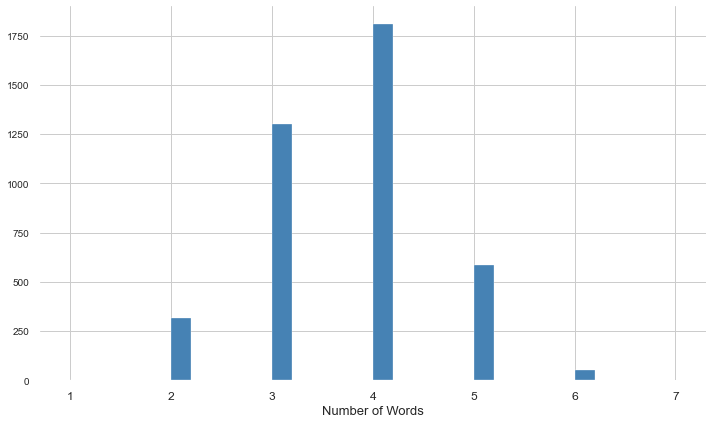

```python
plt.figure(figsize=(10,6))

products_clean['tokenized_description'].map(len).hist(bins=30, color='steelblue')

plt.xlabel('Number of Words', fontsize=13)
plt.xticks(fontsize=12)
plt.tight_layout()
```

After cleaning, we only have products in the dataframe. Is there more than one description per product?

```python
# Products with more than one description
products_clean[
               'lowercase_stockcode'
              ].value_counts()[products_clean['lowercase_stockcode'].value_counts() > 1]
```

```
23131     4
23236     4
23196     4
23240     3
22937     3
         ..
23061     2
23041     2
22502     2
79030d    2
23497     2
Name: lowercase_stockcode, Length: 240, dtype: int64
```

Looking at stock code **23196**, we can see that the descriptions are similar, but there are grammatical errors and/or some adjectives.

```python
products_clean[products_clean['lowercase_stockcode'] == '23196']
```

|  | lowercase_stockcode | lowercase_description | cleanned_description | tokenized_description |
| --- | --- | --- | --- | --- |
| 237422 | 23196 | retro leaves magnetic notepad | retro leav magnet notepad | [retro, leav, magnet, notepad] |
| 238991 | 23196 | reto leaves magnetic shopping list | reto leav magnet shop list | [reto, leav, magnet, shop, list] |
| 246802 | 23196 | leaves magnetic shopping list | leav magnet shop list | [leav, magnet, shop, list] |
| 252851 | 23196 | vintage leaf magnetic notepad | vintag leaf magnet notepad | [vintag, leaf, magnet, notepad] |

If there were different stock codes for the same product with diferent colors or some other characteristic, it would be great. We can't change that, but we can reduce it to just one description per product. We do not want to lose information, so we will keep the description with greater number of words and discard the rest.

```python
# Size of description
pd.DataFrame(zip(products_clean['lowercase_stockcode'],
                 products_clean['tokenized_description'].map(len)),
             columns=['stock_code', 'desc_length'],
             index=products_clean.index)
```

|  | stock_code | desc_length |
| --- | --- | --- |
| 0 | 85123a | 4 |
| 1 | 71053 | 2 |
| 2 | 84406b | 5 |
| 3 | 84029g | 6 |
| 4 | 84029e | 3 |
| ... | ... | ... |
| 510117 | 20711 | 2 |
| 512588 | 23617 | 5 |
| 527065 | 90214u | 5 |
| 537621 | 85123a | 5 |
| 540421 | 23843 | 4 |

4063 rows × 2 columns

```python
# Sorting by stock code
descSize = pd.DataFrame(zip(products_clean['lowercase_stockcode'],
                            products_clean['tokenized_description'].map(len)),
                        columns=['stock_code', 'desc_length'],
                        index=products_clean.index).sort_values('stock_code')
```

```python
# Keeps the longer description

index = 0
indexToKeep = []

while(index != descSize.shape[0]):

    # Calculate the range with the same stock code
    count = 0
    count += descSize[descSize['stock_code'] == descSize.iloc[index]['stock_code']]['stock_code'].count()

    # Finds the description with more words in the range
    indexToKeep.append(descSize['desc_length'].iloc[index:(index+count)].idxmax())

    index += count
```

```python
products_clean = products_clean.loc[indexToKeep]
```

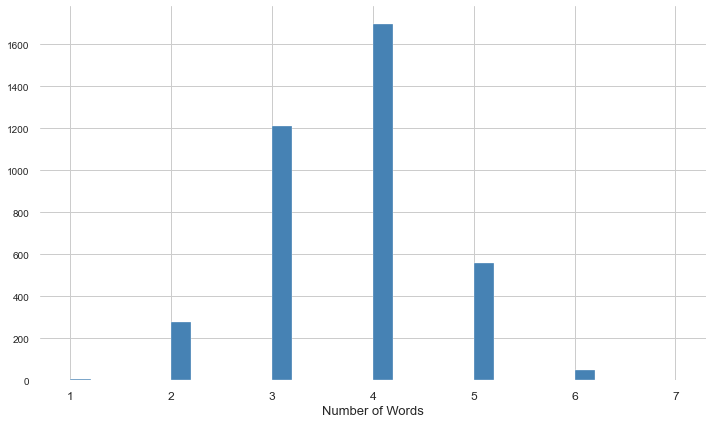

```python
plt.figure(figsize=(10,6))

products_clean['tokenized_description'].map(len).hist(bins=30, color='steelblue')

plt.xlabel('Number of Words', fontsize=13)
plt.xticks(fontsize=12)
plt.tight_layout()
```

We now have clean descriptions with no duplicates.

### 3.2) Product Clustering

It's time to group products by description and identify which category each cluster represents. For this task, I will choose a simple path using the **K-Means** approach.

Feature extraction is not an easy thing when it comes to product clustering. I will use 2 methods: **CountVectorizer** and **TF-IDF**.

### Count Vectorizer

CountVectorizer will only convert our text into a vector of token counts. There is no type of weight based on the "relevance" of a word in the vector, being one of the most simple ways to approach this problem.

```python
vectorizer = CountVectorizer()

# Tokenize and build vocab
vectorizer.fit(products_clean['cleanned_description'])
```

```
CountVectorizer(analyzer='word', binary=False, decode_error='strict',
                dtype=<class 'numpy.int64'>, encoding='utf-8', input='content',
                lowercase=True, max_df=1.0, max_features=None, min_df=1,
                ngram_range=(1, 1), preprocessor=None, stop_words=None,
                strip_accents=None, token_pattern='(?u)\\b\\w\\w+\\b',
                tokenizer=None, vocabulary=None)
```

```python
#vectorizer.vocabulary_
```

```python
# Encode document
vector = vectorizer.transform(products_clean['cleanned_description'])

# Summarize encoded vector
pd.DataFrame(vector.toarray(), columns=vectorizer.get_feature_names())
```

|  | abc | abstract | acapulco | account | acryl | address | ade | adult | advent | afghan | ... | xcm | xma | yellowblu | yelloworang | yellowpink | your | yuletid | zero | zinc | zincglass |
| --- | --- | --- | --- | --- | --- | --- | --- | --- | --- | --- | --- | --- | --- | --- | --- | --- | --- | --- | --- | --- | --- |
| 0 | 0 | 0 | 0 | 0 | 0 | 0 | 0 | 0 | 0 | 0 | ... | 0 | 0 | 0 | 0 | 0 | 0 | 0 | 0 | 0 | 0 |
| 1 | 0 | 0 | 0 | 0 | 0 | 0 | 0 | 0 | 0 | 0 | ... | 0 | 0 | 0 | 0 | 0 | 0 | 0 | 0 | 0 | 0 |
| 2 | 0 | 0 | 0 | 0 | 0 | 0 | 0 | 0 | 0 | 0 | ... | 0 | 0 | 0 | 0 | 0 | 0 | 0 | 0 | 0 | 0 |
| 3 | 0 | 0 | 0 | 0 | 0 | 0 | 0 | 0 | 0 | 0 | ... | 0 | 0 | 0 | 0 | 0 | 0 | 0 | 0 | 0 | 0 |
| 4 | 0 | 0 | 0 | 0 | 0 | 0 | 0 | 0 | 0 | 0 | ... | 0 | 0 | 0 | 0 | 0 | 0 | 0 | 0 | 0 | 0 |
| ... | ... | ... | ... | ... | ... | ... | ... | ... | ... | ... | ... | ... | ... | ... | ... | ... | ... | ... | ... | ... | ... |
| 3795 | 0 | 0 | 0 | 0 | 0 | 0 | 0 | 0 | 0 | 0 | ... | 0 | 0 | 0 | 0 | 0 | 0 | 0 | 0 | 0 | 0 |
| 3796 | 0 | 0 | 0 | 0 | 0 | 0 | 0 | 0 | 0 | 0 | ... | 0 | 0 | 0 | 0 | 0 | 0 | 0 | 0 | 0 | 0 |
| 3797 | 0 | 0 | 0 | 0 | 0 | 0 | 0 | 0 | 0 | 0 | ... | 0 | 0 | 0 | 0 | 0 | 0 | 0 | 0 | 0 | 0 |
| 3798 | 0 | 0 | 0 | 0 | 0 | 0 | 0 | 0 | 0 | 0 | ... | 0 | 0 | 0 | 0 | 0 | 0 | 0 | 0 | 0 | 0 |
| 3799 | 0 | 0 | 0 | 0 | 0 | 0 | 0 | 0 | 0 | 0 | ... | 0 | 0 | 0 | 0 | 0 | 0 | 0 | 0 | 0 | 0 |

3800 rows × 1791 columns

There is no clue as to how many groups we are looking for, how many product categories there are. Let's use the **Elbow Method** to help us find a good K value.

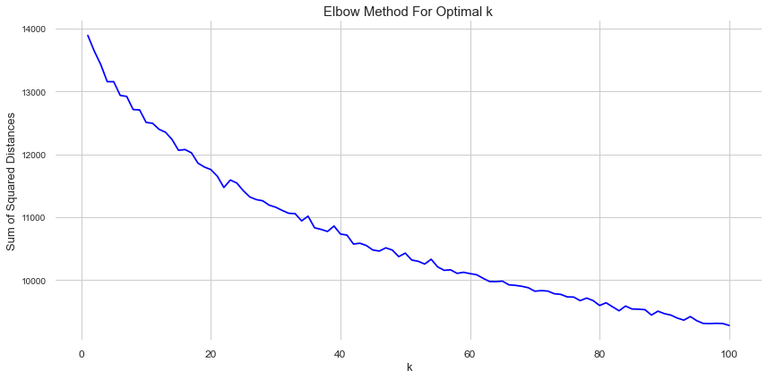

```python
# Determine k using elbow method

Sum_of_squared_distances = []

# There are 3800 product description
# It is reasonable to think that there can be 100 groups of 38 products each
K = range(1, 101)
for k in K:
    km = KMeans(n_clusters=k)
    km = km.fit(vector)
    Sum_of_squared_distances.append(km.inertia_)

plt.figure(figsize=(12,6))

plt.plot(K, Sum_of_squared_distances, 'bx-')

plt.xlabel('k', fontsize=13)
plt.ylabel('Sum of Squared Distances', fontsize=13)
plt.title('Elbow Method For Optimal k', fontsize=15)

plt.xticks(fontsize=12)
plt.tight_layout()
```

It is not easy to say exactly where the "elbow" is, but choosing the number of clusters equal to 35 (K = 35) is quite fair.

```python
K = 35

km = KMeans(n_clusters=K)
km.fit(vector)
```

```
KMeans(algorithm='auto', copy_x=True, init='k-means++', max_iter=300,
       n_clusters=35, n_init=10, n_jobs=None, precompute_distances='auto',
       random_state=None, tol=0.0001, verbose=0)
```

```python
km.labels_
```

```
array([12, 12, 12, ..., 33, 10, 10])
```

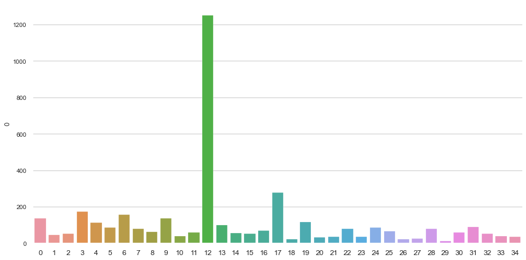

```python
plt.figure(figsize=(12,6))

sns.barplot(x=pd.DataFrame(km.labels_)[0].value_counts().index, y=pd.DataFrame(km.labels_)[0].value_counts())
plt.xticks(fontsize=12)
plt.tight_layout()
```

```python
prod_clusters = pd.DataFrame({
                              'lowercase_description': products_clean['lowercase_description'],
                              'cleanned_description': products_clean['cleanned_description'],
                              'category': km.labels_
                             })
```

```python
prod_clusters
```

|  | lowercase_description | cleanned_description | category |
| --- | --- | --- | --- |
| 31 | inflatable political globe | inflat polit globe | 12 |
| 103332 | groovy cactus inflatable | groovi cactu inflat | 12 |
| 5452 | doggy rubber | doggi rubber | 12 |
| 5451 | hearts wrapping tape | heart wrap tape | 6 |
| 12492 | spots on red bookcover tape | spot bookcov tape | 12 |
| ... | ... | ... | ... |
| 170783 | haynes camper shoulder bag | hayn camper shoulder bag | 4 |
| 40052 | camouflage dog collar | camouflag dog collar | 12 |
| 21326 | sunjar led night night light | sunjar led night night light | 33 |
| 84016 | boys party bag | boy parti bag | 10 |
| 84017 | girls party bag | girl parti bag | 10 |

3800 rows × 3 columns

It is difficult to measure whether the clusterings are correct or not. I will create a dataframe where each row is a group/category and the columns are samples of product descriptions from the same cluster.

This way, our metrics will be common sense. The more it make sense, the better.

```python
# Top descriptions per cluster
# The lowercase_description column position is 0 (first column)

top_desc_cluster = pd.DataFrame({
                                 'category': 0,
                                 'desc_1': prod_clusters[prod_clusters['category'] == 0].iloc[0, 0],
                                 'desc_2': prod_clusters[prod_clusters['category'] == 0].iloc[1, 0],
                                 'desc_3': prod_clusters[prod_clusters['category'] == 0].iloc[2, 0],
                                 'desc_4': prod_clusters[prod_clusters['category'] == 0].iloc[3, 0],
                                 'desc_5': prod_clusters[prod_clusters['category'] == 0].iloc[4, 0]
                                }, index=[0])

for cluster in range(1, K):

    top_desc_cluster = pd.concat([top_desc_cluster,
                                  pd.DataFrame({
                                 'category': cluster,
                                 'desc_1': prod_clusters[prod_clusters['category'] == cluster].iloc[0, 0],
                                 'desc_2': prod_clusters[prod_clusters['category'] == cluster].iloc[1, 0],
                                 'desc_3': prod_clusters[prod_clusters['category'] == cluster].iloc[2, 0],
                                 'desc_4': prod_clusters[prod_clusters['category'] == cluster].iloc[3, 0],
                                 'desc_5': prod_clusters[prod_clusters['category'] == cluster].iloc[4, 0]
                                }, index=[0])],
                                  ignore_index=True)
```

```python
top_desc_cluster
```

|  | category | desc_1 | desc_2 | desc_3 | desc_4 | desc_5 |
| --- | --- | --- | --- | --- | --- | --- |
| 0 | 0 | clear stationery box set | box of 9 pebble candles | vintage keepsake box pink flower | vintage keepsake box paris days | vintage keepsake box travelogue |
| 1 | 1 | colouring pencils brown tube | colouring pencils brown tube | assorted colours silk fan | popart wooden pencils asst | teatime round pencil sharpener |
| 2 | 2 | glitter hanging butterfly string | pink poodle hanging decoration | ivory hanging decoration heart | ivory hanging decoration egg | ivory hanging decoration bird |
| 3 | 3 | vintage notebook paris days | vintage notebook travelogue | vintage notebook beauty girl | vintage photo album paris days | set/4 modern vintage cotton napkins |
| 4 | 4 | the king gift bag | funky monkey gift bag medium | swirly circular rubbers in bag | jumbo bag toys | jumbo bag woodland animals |
| 5 | 5 | asstd design racing car pen | ice cream design garden parasol | key fob , garage design | skulls design flannel | cakes and rabbits design flannel |
| 6 | 6 | hearts wrapping tape | red purse with pink heart | pink heart red handbag | red heart luggage tag | zinc heart lattice 2 wall planter |
| 7 | 7 | porcelain budah incense holder | assorted laquered incense holders | pink tall porcelain t-light holder | white tall porcelain t-light holder | zinc heart lattice t-light holder |
| 8 | 8 | small folding scissor(pointed edge) | small chinese style scissor | ass col small sand gecko p'weight | small blue provencal ceramic ball | small glass sundae dish clear |
| 9 | 9 | wrap english rose | origami rose incense in tube | blue stones on wire for candle | blue rose patch purse pink butterfl | blue rose fabric mirror |
| 10 | 10 | party time pencil erasers | party food shopper bag | party invites woodland | party invites dinosaurs | party invites balloon girl |
| 11 | 11 | large chinese style scissor | ass col large sand frog p'weight | large black diamante hairslide | large blue provencal ceramic ball | large pink glass sundae dish |
| 12 | 12 | inflatable political globe | groovy cactus inflatable | doggy rubber | spots on red bookcover tape | army camo bookcover tape |
| 13 | 13 | blue glass gems in bag | clear milkshake glass | silver aperitif glass | gold aperitif glass | antique all glass candlestick |
| 14 | 14 | beware of the cat metal sign | cook with wine metal sign | you're confusing me metal sign | bathroom metal sign | party metal sign |
| 15 | 15 | black ear muff headphones | gold ear muff headphones | camouflage ear muff headphones | antique raspberry flower earrings | antique mid blue flower earrings |
| 16 | 16 | fairy cake design umbrella | wrap pink fairy cakes | fairy cake flannel assorted colour | pack of 72 retrospot cake cases | pack of 72 skull cake cases |
| 17 | 17 | piece of camo stationery set | origami vanilla incense/candle set | origami jasmine incense/candle set | origami lavender incense/candl set | origami rose incense/candle set |
| 18 | 18 | home sweet home metal sign | doormat fancy font home sweet home | doormat spotty home sweet home | home sweet home mug | paperweight home sweet home |
| 19 | 19 | blue polkadot garden parasol | pink polkadot garden parasol | pop art push down rubber | garden path pocket book | garden path sketchbook |
| 20 | 20 | ribbons purse | mummy mouse red gingham ribbon | 6 ribbons shimmering pinks | 6 ribbons empire | 6 ribbons rustic charm |
| 21 | 21 | dolly mixture children's umbrella | moody girl door hanger | keep out girls door hanger | tv dinner tray dolly girl | magic drawing slate dolly girl |
| 22 | 22 | flowers handbag blue and orange | flower fairy,5 summer b'draw liners | flower fairy incense bouquet | rose flower candle+incense 16x16cm | toast its - fairy flower |
| 23 | 23 | mini funky design tapes | mini highlighter pens | gold mini tape measure | silver mini tape measure | black mini tape measure |
| 24 | 24 | disco ball christmas decoration | crazy daisy heart decoration | etched glass star tree decoration | glitter snow pear tree decoration | swiss chalet tree decoration |
| 25 | 25 | blue polkadot passport cover | cherry blossom passport cover | first class passport cover | queen of the skies passport cover | tropical passport cover |
| 26 | 26 | tumbler, baroque | new baroque jewellery box | pink new baroque flock candlestick | blue new baroque flock candlestick | new baroque black boxes |
| 27 | 27 | key ring baseball boot assorted | key ring baseball boot union jack | bling key ring stand | letter "a" bling key ring | letter "b" bling key ring |
| 28 | 28 | raspberry ant copper flower necklac | midnight blue copper flower necklac | copper/olive green flower necklace | midnight blue drop crystal necklace | black drop crystal necklace |
| 29 | 29 | balloon art make your own flowers | art lights,funk monkey | large white/pink rose art flower | medium white/pink rose art flower | small white/pink rose art flower |
| 30 | 30 | rattle snake eggs | blue polkadot egg cup | red egg spoon | blue egg spoon | 2 picture book eggs easter chicks |
| 31 | 31 | wrap 50's christmas | bird box christmas tree decoration | christmas toilet roll | green goose feather christmas tree | white goose feather christmas tree |
| 32 | 32 | fan black frame | pastel pink photo album | pastel blue photo album | black photo album | maxwell 2 tone blue 60 page photo a |
| 33 | 33 | red toadstool led night light | star portable table light | snowflake portable table light | set 10 night owl lights | pig keyring with light & sound |
| 34 | 34 | red stripe ceramic drawer knob | blue stripe ceramic drawer knob | blue spot ceramic drawer knob | red spot ceramic drawer knob | white spot red ceramic drawer knob |

There is some correlation between the products of the same cluster, but it is far from what we want. I will move on to the next approach.

### TF-IDF

```python
vectorizer = TfidfVectorizer()

# Tokenize and build vocab
vectorizer.fit(products_clean['cleanned_description'])
```

```
TfidfVectorizer(analyzer='word', binary=False, decode_error='strict',
                dtype=<class 'numpy.float64'>, encoding='utf-8',
                input='content', lowercase=True, max_df=1.0, max_features=None,
                min_df=1, ngram_range=(1, 1), norm='l2', preprocessor=None,
                smooth_idf=True, stop_words=None, strip_accents=None,
                sublinear_tf=False, token_pattern='(?u)\\b\\w\\w+\\b',
                tokenizer=None, use_idf=True, vocabulary=None)
```

```python
#vectorizer.vocabulary_
```

```python
# Encode document
vector = vectorizer.transform(products_clean['cleanned_description'])

# Summarize encoded vector
pd.DataFrame(vector.toarray(), columns=vectorizer.get_feature_names())
```

|  | abc | abstract | acapulco | account | acryl | address | ade | adult | advent | afghan | ... | xcm | xma | yellowblu | yelloworang | yellowpink | your | yuletid | zero | zinc | zincglass |
| --- | --- | --- | --- | --- | --- | --- | --- | --- | --- | --- | --- | --- | --- | --- | --- | --- | --- | --- | --- | --- | --- |
| 0 | 0.0 | 0.0 | 0.0 | 0.0 | 0.0 | 0.0 | 0.0 | 0.0 | 0.0 | 0.0 | ... | 0.0 | 0.0 | 0.0 | 0.0 | 0.0 | 0.0 | 0.0 | 0.0 | 0.0 | 0.0 |
| 1 | 0.0 | 0.0 | 0.0 | 0.0 | 0.0 | 0.0 | 0.0 | 0.0 | 0.0 | 0.0 | ... | 0.0 | 0.0 | 0.0 | 0.0 | 0.0 | 0.0 | 0.0 | 0.0 | 0.0 | 0.0 |
| 2 | 0.0 | 0.0 | 0.0 | 0.0 | 0.0 | 0.0 | 0.0 | 0.0 | 0.0 | 0.0 | ... | 0.0 | 0.0 | 0.0 | 0.0 | 0.0 | 0.0 | 0.0 | 0.0 | 0.0 | 0.0 |
| 3 | 0.0 | 0.0 | 0.0 | 0.0 | 0.0 | 0.0 | 0.0 | 0.0 | 0.0 | 0.0 | ... | 0.0 | 0.0 | 0.0 | 0.0 | 0.0 | 0.0 | 0.0 | 0.0 | 0.0 | 0.0 |
| 4 | 0.0 | 0.0 | 0.0 | 0.0 | 0.0 | 0.0 | 0.0 | 0.0 | 0.0 | 0.0 | ... | 0.0 | 0.0 | 0.0 | 0.0 | 0.0 | 0.0 | 0.0 | 0.0 | 0.0 | 0.0 |
| ... | ... | ... | ... | ... | ... | ... | ... | ... | ... | ... | ... | ... | ... | ... | ... | ... | ... | ... | ... | ... | ... |
| 3795 | 0.0 | 0.0 | 0.0 | 0.0 | 0.0 | 0.0 | 0.0 | 0.0 | 0.0 | 0.0 | ... | 0.0 | 0.0 | 0.0 | 0.0 | 0.0 | 0.0 | 0.0 | 0.0 | 0.0 | 0.0 |
| 3796 | 0.0 | 0.0 | 0.0 | 0.0 | 0.0 | 0.0 | 0.0 | 0.0 | 0.0 | 0.0 | ... | 0.0 | 0.0 | 0.0 | 0.0 | 0.0 | 0.0 | 0.0 | 0.0 | 0.0 | 0.0 |
| 3797 | 0.0 | 0.0 | 0.0 | 0.0 | 0.0 | 0.0 | 0.0 | 0.0 | 0.0 | 0.0 | ... | 0.0 | 0.0 | 0.0 | 0.0 | 0.0 | 0.0 | 0.0 | 0.0 | 0.0 | 0.0 |
| 3798 | 0.0 | 0.0 | 0.0 | 0.0 | 0.0 | 0.0 | 0.0 | 0.0 | 0.0 | 0.0 | ... | 0.0 | 0.0 | 0.0 | 0.0 | 0.0 | 0.0 | 0.0 | 0.0 | 0.0 | 0.0 |
| 3799 | 0.0 | 0.0 | 0.0 | 0.0 | 0.0 | 0.0 | 0.0 | 0.0 | 0.0 | 0.0 | ... | 0.0 | 0.0 | 0.0 | 0.0 | 0.0 | 0.0 | 0.0 | 0.0 | 0.0 | 0.0 |

3800 rows × 1791 columns

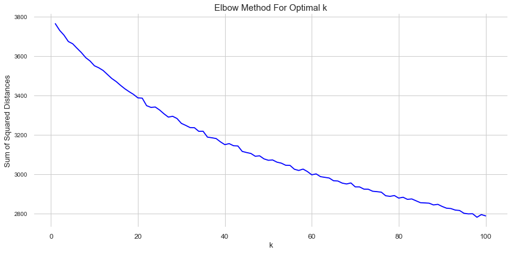

```python
# Determine k using elbow method

Sum_of_squared_distances = []

# There are 3800 product description
# It is reasonable to think that there can be 100 groups of 38 products each
K = range(1, 101)
for k in K:
    km = KMeans(n_clusters=k)
    km = km.fit(vector)
    Sum_of_squared_distances.append(km.inertia_)

plt.figure(figsize=(12,6))

plt.plot(K, Sum_of_squared_distances, 'bx-')

plt.xlabel('k', fontsize=13)
plt.ylabel('Sum of Squared Distances', fontsize=13)
plt.title('Elbow Method For Optimal k', fontsize=15)

plt.xticks(fontsize=12)
plt.tight_layout()
```

```python
# This time, 36 seems to be reasonable number
K = 36

km = KMeans(n_clusters=K)
km.fit(vector)
```

```
KMeans(algorithm='auto', copy_x=True, init='k-means++', max_iter=300,
       n_clusters=36, n_init=10, n_jobs=None, precompute_distances='auto',
       random_state=None, tol=0.0001, verbose=0)
```

```python
km.labels_
```

```
array([ 5,  5,  5, ...,  5, 23, 23])
```

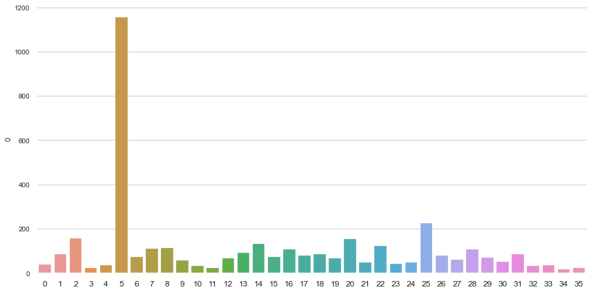

```python
plt.figure(figsize=(12,6))

sns.barplot(x=pd.DataFrame(km.labels_)[0].value_counts().index, y=pd.DataFrame(km.labels_)[0].value_counts())
plt.xticks(fontsize=12)
plt.tight_layout()
```

```python
prod_clusters = pd.DataFrame({
                              'lowercase_description': products_clean['lowercase_description'],
                              'cleanned_description': products_clean['cleanned_description'],
                              'category': km.labels_
                             })
```

```python
prod_clusters
```

|  | lowercase_description | cleanned_description | category |
| --- | --- | --- | --- |
| 31 | inflatable political globe | inflat polit globe | 5 |
| 103332 | groovy cactus inflatable | groovi cactu inflat | 5 |
| 5452 | doggy rubber | doggi rubber | 5 |
| 5451 | hearts wrapping tape | heart wrap tape | 7 |
| 12492 | spots on red bookcover tape | spot bookcov tape | 10 |
| ... | ... | ... | ... |
| 170783 | haynes camper shoulder bag | hayn camper shoulder bag | 5 |
| 40052 | camouflage dog collar | camouflag dog collar | 5 |
| 21326 | sunjar led night night light | sunjar led night night light | 5 |
| 84016 | boys party bag | boy parti bag | 23 |
| 84017 | girls party bag | girl parti bag | 23 |

3800 rows × 3 columns

```python
# Top descriptions per cluster
# The lowercase_description column position is 0 (first column)

top_desc_cluster = pd.DataFrame({
                                 'category': 0,
                                 'desc_1': prod_clusters[prod_clusters['category'] == 0].iloc[0, 0],
                                 'desc_2': prod_clusters[prod_clusters['category'] == 0].iloc[1, 0],
                                 'desc_3': prod_clusters[prod_clusters['category'] == 0].iloc[2, 0],
                                 'desc_4': prod_clusters[prod_clusters['category'] == 0].iloc[3, 0],
                                 'desc_5': prod_clusters[prod_clusters['category'] == 0].iloc[4, 0]
                                }, index=[0])

for cluster in range(1, K):

    top_desc_cluster = pd.concat([top_desc_cluster,
                                  pd.DataFrame({
                                 'category': cluster,
                                 'desc_1': prod_clusters[prod_clusters['category'] == cluster].iloc[0, 0],
                                 'desc_2': prod_clusters[prod_clusters['category'] == cluster].iloc[1, 0],
                                 'desc_3': prod_clusters[prod_clusters['category'] == cluster].iloc[2, 0],
                                 'desc_4': prod_clusters[prod_clusters['category'] == cluster].iloc[3, 0],
                                 'desc_5': prod_clusters[prod_clusters['category'] == cluster].iloc[4, 0]
                                }, index=[0])],
                                  ignore_index=True)
```

```python
top_desc_cluster
```

|  | category | desc_1 | desc_2 | desc_3 | desc_4 | desc_5 |
| --- | --- | --- | --- | --- | --- | --- |
| 0 | 0 | silver looking mirror | goldie looking mirror | blue rose fabric mirror | pink rose fabric mirror | silver fabric mirror |
| 1 | 1 | crazy daisy heart decoration | etched glass star tree decoration | glitter snow pear tree decoration | swiss chalet tree decoration | dark bird house tree decoration |
| 2 | 2 | blue stones on wire for candle | red retrospot luggage tag | red retrospot purse | red retrospot bowl | red retrospot childrens umbrella |
| 3 | 3 | vintage union jack bunting | vintage union jack cushion cover | vintage union jack memoboard | vintage union jack doorstop | vintage union jack apron |
| 4 | 4 | french style embossed heart cabinet | french lavender scent heart | classic french style basket green | classic french style basket brown | classic french style basket natural |
| 5 | 5 | inflatable political globe | groovy cactus inflatable | doggy rubber | army camo bookcover tape | colouring pencils brown tube |
| 6 | 6 | zinc heart lattice 2 wall planter | set of skull wall stickers | mirrored dove wall decoration | mirrored wall art stars | mirrored wall art photo frames |
| 7 | 7 | hearts wrapping tape | wrap, carousel | wrap bad hair day | wrap pink flock | wrap english rose |
| 8 | 8 | wrap 50's christmas | disco ball christmas decoration | set/9 christmas t-lights scented | bird box christmas tree decoration | christmas toilet roll |
| 9 | 9 | blue polkadot garden parasol | pink polkadot garden parasol | blue polkadot passport cover | blue polkadot luggage tag | blue polkadot purse |
| 10 | 10 | spots on red bookcover tape | cream slice flannel chocolate spot | cream slice flannel pink spot | large cake towel, chocolate spots | large cake towel pink spots |
| 11 | 11 | bling key ring stand | letter "a" bling key ring | letter "b" bling key ring | letter "d" bling key ring | letter "e" bling key ring |
| 12 | 12 | black ear muff headphones | gold ear muff headphones | camouflage ear muff headphones | midnight blue crystal drop earrings | black crystal drop earrings |
| 13 | 13 | midnight blue copper flower necklac | copper/olive green flower necklace | midnight blue drop crystal necklace | black drop crystal necklace | silver/mop orbit necklace |
| 14 | 14 | mini funky design tapes | asstd design racing car pen | vintage red mug | vintage red teatime mug | vintage billboard love/hate mug |
| 15 | 15 | ice cream design garden parasol | mini highlighter pens | gold mini tape measure | silver mini tape measure | black mini tape measure |
| 16 | 16 | flowers handbag blue and orange | flower fairy,5 summer b'draw liners | flower fairy incense bouquet | rose flower candle+incense 16x16cm | toast its - fairy flower |
| 17 | 17 | fairy cake design umbrella | wrap pink fairy cakes | pack of 72 retrospot cake cases | pack of 72 skull cake cases | ivory paper cup cake cases |
| 18 | 18 | rattle snake eggs | 2 picture book eggs easter chicks | 2 picture book eggs easter ducks | 2 picture book eggs easter bunny | yellow easter egg hunt start post |
| 19 | 19 | midnight blue glass/silver bracelet | black/white glass/silver bracelet | amber glass/silver bracelet | silver m.o.p orbit bracelet | gold m.o.p orbit bracelet |
| 20 | 20 | small folding scissor(pointed edge) | small chinese style scissor | red purse with pink heart | pink heart red handbag | red heart luggage tag |
| 21 | 21 | love potion masala incense | red flock love heart photo frame | toast its - i love you | love large wood letters | red heart shape love bucket |
| 22 | 22 | skulls greeting card | fancy font birthday card, | elephant birthday card | vintage kid dolly card | cowboys and indians birthday card |
| 23 | 23 | party time pencil erasers | party food shopper bag | party invites woodland | party invites dinosaurs | party invites balloon girl |
| 24 | 24 | large black diamante hairslide | pink diamante pen in gift box | green diamante pen in gift box | silver diamante pen in gift box | blue diamante pen in gift box |
| 25 | 25 | piece of camo stationery set | origami vanilla incense/candle set | origami jasmine incense/candle set | origami lavender incense/candl set | origami rose incense/candle set |
| 26 | 26 | victorian metal postcard spring | home sweet home metal sign | beware of the cat metal sign | cook with wine metal sign | you're confusing me metal sign |
| 27 | 27 | s/3 pot pouri cushions blue colours | cherry blossom passport cover | first class passport cover | queen of the skies passport cover | tropical passport cover |
| 28 | 28 | clear stationery box set | box of 9 pebble candles | vintage keepsake box pink flower | vintage keepsake box paris days | vintage keepsake box travelogue |
| 29 | 29 | pink tall porcelain t-light holder | white tall porcelain t-light holder | zinc heart lattice t-light holder | hanging bauble t-light holder small | hanging bauble t-light holder large |
| 30 | 30 | assorted colours silk fan | assorted incense pack | assorted laquered incense holders | assorted colour mini cases | funky washing up gloves assorted |
| 31 | 31 | blue glass gems in bag | clear milkshake glass | large pink glass sundae dish | small glass sundae dish clear | small pink glass sundae dish |
| 32 | 32 | pack of 12 skull tissues | pack of 12 red retrospot tissues | pack of 12 woodland tissues | pack of 12 suki tissues | pack of 12 blue paisley tissues |
| 33 | 33 | white skull hot water bottle | fawn blue hot water bottle | chick grey hot water bottle | retrospot heart hot water bottle | pink heart dots hot water bottle |
| 34 | 34 | vintage kitchen print puddings | red polkadot pudding bowl | blue polkadot pudding bowl | red pudding spoon | blue pudding spoon |
| 35 | 35 | blue tiled tray | blue tile hook | number tile cottage garden 0 | number tile cottage garden 1 | number tile cottage garden 2 |

```python
products_clean[products_clean['lowercase_description'] == 'colouring pencils brown tube']
```

|  | lowercase_stockcode | lowercase_description | cleanned_description | tokenized_description |
| --- | --- | --- | --- | --- |
| 741 | 10133 | colouring pencils brown tube | colour pencil tube | [colour, pencil, tube] |
| 2461 | 10135 | colouring pencils brown tube | colour pencil tube | [colour, pencil, tube] |

The **TF-IDF** approach seems to be better than **CountVectorizer**. Clusters appear to be more concise. There are more than one product with the same description, but I will assume they are different.

In both approachs, there are clusters that stand out for the discrepant number of products. Next time, I will apply the same method to these clusters and create subcategories.